# Setup

### Self-Efficacy

We first compare likes and likes plus dislikes to the control condition.

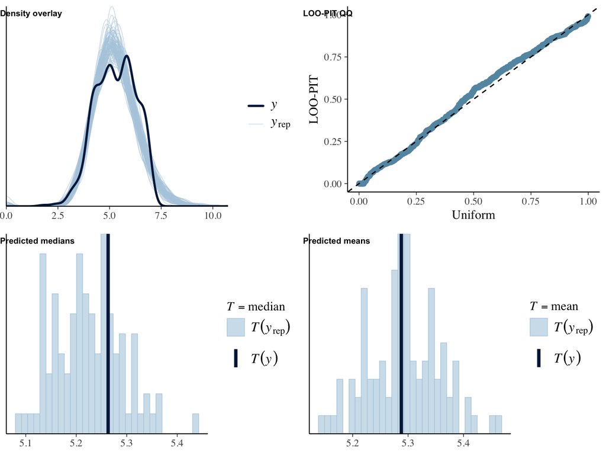

```
 Family: hurdle_gamma
  Links: mu = log; hu = logit
Formula: self_eff_fs ~ 1 + age + male + edu + version
         hu ~ 1 + age + male + edu + version
   Data: object (Number of observations: 558)
  Draws: 4 chains, each with iter = 1000; warmup = 500; thin = 1;
         total post-warmup draws = 2000

Regression Coefficients:
                       Estimate Est.Error l-95% CI u-95% CI Rhat Bulk_ESS Tail_ESS
Intercept                  1.63      0.03     1.56     1.69 1.00     2558     1711
hu_Intercept              -9.91      6.13   -23.73     0.33 1.00      899      845
age                       -0.00      0.00    -0.00     0.00 1.00     2293     1531
male                       0.02      0.02    -0.02     0.05 1.00     1856     1602
edu                        0.02      0.01     0.01     0.04 1.00     2477     1427
versionLike               -0.02      0.02    -0.05     0.02 1.00     1470     1596
versionLike&dislike       -0.02      0.02    -0.06     0.02 1.00     1762     1532
hu_age                     0.00      0.08    -0.16     0.17 1.00     1269     1309
hu_male                    0.11      3.56    -6.91     7.46 1.01      690      325
hu_edu                    -0.33      1.69    -4.02     2.76 1.00     1668     1097
hu_versionLike            -0.15      4.49    -9.54     9.17 1.00      786      578
hu_versionLike&dislike    -0.24      4.66    -9.97     8.83 1.01      916      618

Further Distributional Parameters:
      Estimate Est.Error l-95% CI u-95% CI Rhat Bulk_ESS Tail_ESS
shape    27.93      1.66    24.65    31.30 1.00     2341     1497

Draws were sampled using sampling(NUTS). For each parameter, Bulk_ESS
and Tail_ESS are effective sample size measures, and Rhat is the potential
scale reduction factor on split chains (at convergence, Rhat = 1).
```

```
Results of marginal effects:
      Outcome    term                 contrast  estimate conf.low conf.high
1 self_eff_fs     age                    dY/dX -0.000383 -0.00616   0.00523
2 self_eff_fs     edu                    dY/dX  0.132359  0.02649   0.24383
3 self_eff_fs    male                    1 - 0  0.084321 -0.09861   0.25721
4 self_eff_fs version Like & dislike - Control -0.093925 -0.30783   0.12137
5 self_eff_fs version           Like - Control -0.093625 -0.29311   0.11321
```

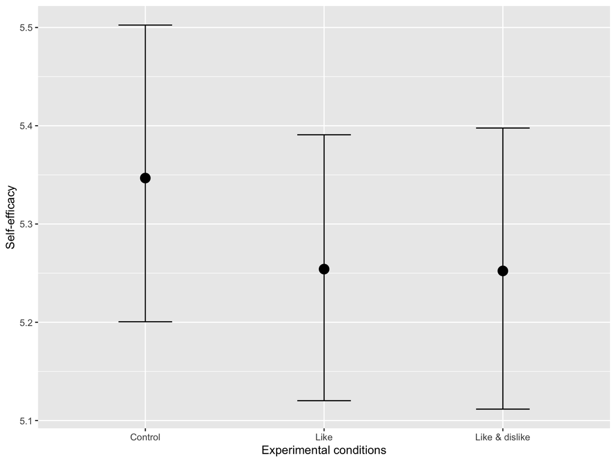

```r
run_hurdles(
  object = d,
  name = "selfeff_ctrl",
  outcome = "self_eff_fs",
  predictor = "version",
  y_lab = "Self-efficacy",
  x_lab = "Experimental conditions"
  )
```

We then compare the likes and control conditions to the likes plus dislikes condition.

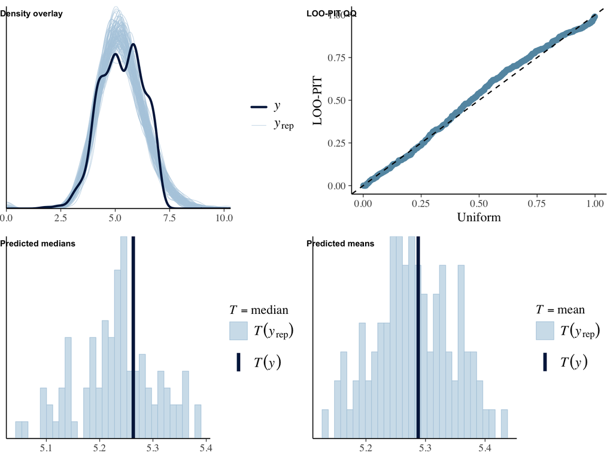

```
 Family: hurdle_gamma
  Links: mu = log; hu = logit
Formula: self_eff_fs ~ 1 + age + male + edu + version_lkdslk
         hu ~ 1 + age + male + edu + version_lkdslk
   Data: object (Number of observations: 558)
  Draws: 4 chains, each with iter = 1000; warmup = 500; thin = 1;
         total post-warmup draws = 2000

Regression Coefficients:
                         Estimate Est.Error l-95% CI u-95% CI Rhat Bulk_ESS Tail_ESS
Intercept                    1.61      0.03     1.54     1.67 1.00     2166     1853
hu_Intercept               -10.24      6.23   -25.23    -0.25 1.00      930      998
age                         -0.00      0.00    -0.00     0.00 1.00     1973     1578
male                         0.02      0.02    -0.01     0.05 1.00     2110     1484
edu                          0.02      0.01     0.01     0.04 1.00     2301     1435
version_lkdslkLike           0.00      0.02    -0.04     0.04 1.00     1373     1244
version_lkdslkControl        0.02      0.02    -0.02     0.06 1.00     1401     1430
hu_age                       0.00      0.09    -0.16     0.18 1.00      940      824
hu_male                     -0.14      3.27    -7.06     6.64 1.00     1186      796
hu_edu                      -0.09      1.69    -3.70     3.25 1.00     1276     1100
hu_version_lkdslkLike       -0.28      4.89   -11.27     9.47 1.00     1025      619
hu_version_lkdslkControl    -0.07      4.50    -9.65     8.75 1.00      783      755

Further Distributional Parameters:
      Estimate Est.Error l-95% CI u-95% CI Rhat Bulk_ESS Tail_ESS
shape    27.92      1.69    24.66    31.32 1.00     1884     1356

Draws were sampled using sampling(NUTS). For each parameter, Bulk_ESS
and Tail_ESS are effective sample size measures, and Rhat is the potential
scale reduction factor on split chains (at convergence, Rhat = 1).
```

```
Results of marginal effects:
      Outcome           term                 contrast  estimate conf.low conf.high
1 self_eff_fs            age                    dY/dX -0.000085 -0.00595   0.00542
2 self_eff_fs            edu                    dY/dX  0.130117  0.02142   0.24129
3 self_eff_fs           male                    1 - 0  0.081208 -0.07935   0.24938
4 self_eff_fs version_lkdslk Control - Like & dislike  0.092689 -0.11843   0.31155
5 self_eff_fs version_lkdslk    Like - Like & dislike  0.000671 -0.21439   0.20989
```

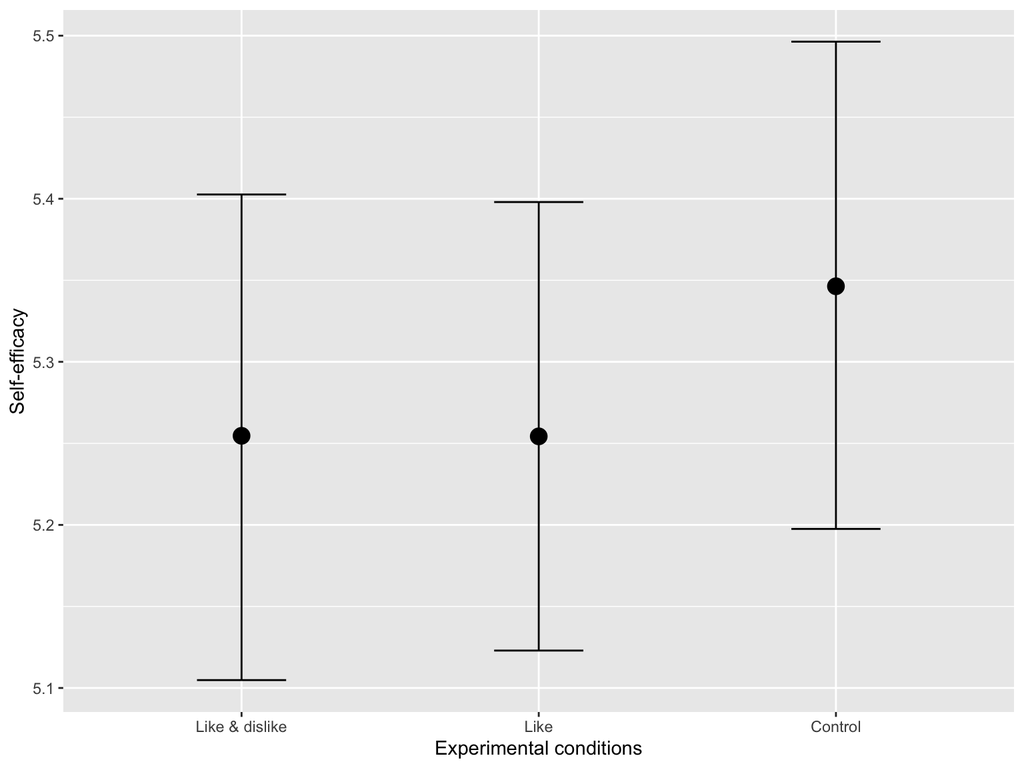

```r
run_hurdles(
  object = d,
  name = "selfeff_lkdslk",
  outcome = "self_eff_fs",
  predictor = "version_lkdslk",
  y_lab = "Self-efficacy",
  x_lab = "Experimental conditions"
  )
```

## Communication

In what follows, we analyze the preregistered outcome, communication, measured as the number of words a participant wrote. All privacy calculus variables are standardized (*z*-scores), so that effects refer to an increase of one standard deviation.

### Experimental Factors

We first compare likes and likes plus dislikes to the control condition.

```
Some PIT values larger than 1! Largest:  1
Rounding PIT > 1 to 1.
```

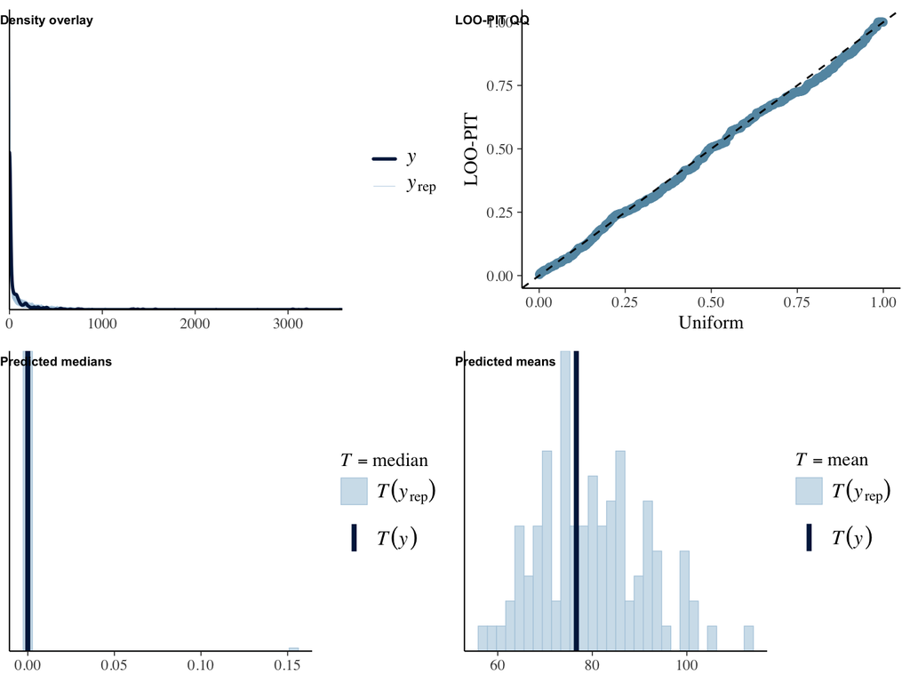

```
 Family: hurdle_gamma
  Links: mu = log; hu = logit
Formula: words ~ 1 + age + male + edu + version
         hu ~ 1 + age + male + edu + version
   Data: object (Number of observations: 558)
  Draws: 4 chains, each with iter = 1000; warmup = 500; thin = 1;
         total post-warmup draws = 2000

Regression Coefficients:
                       Estimate Est.Error l-95% CI u-95% CI Rhat Bulk_ESS Tail_ESS
Intercept                  5.64      0.36     4.93     6.37 1.00     3131     1720
hu_Intercept               1.06      0.37     0.30     1.82 1.01     3517     1542
age                       -0.00      0.01    -0.01     0.01 1.00     3838     1565
male                      -0.18      0.17    -0.51     0.15 1.00     2984     1386
edu                        0.01      0.09    -0.17     0.19 1.00     3820     1363
versionLike               -0.40      0.19    -0.76    -0.02 1.00     3376     1831
versionLike&dislike       -0.47      0.21    -0.87    -0.05 1.00     2895     1731
hu_age                    -0.01      0.01    -0.02     0.00 1.00     4372     1524
hu_male                   -0.06      0.17    -0.39     0.26 1.00     4472     1589
hu_edu                    -0.21      0.10    -0.41     0.00 1.00     3488     1443
hu_versionLike             0.02      0.21    -0.38     0.43 1.00     3147     1597
hu_versionLike&dislike     0.24      0.22    -0.19     0.66 1.00     3077     1760

Further Distributional Parameters:
      Estimate Est.Error l-95% CI u-95% CI Rhat Bulk_ESS Tail_ESS
shape     0.70      0.06     0.59     0.82 1.00     5187     1490

Draws were sampled using sampling(NUTS). For each parameter, Bulk_ESS
and Tail_ESS are effective sample size measures, and Rhat is the potential
scale reduction factor on split chains (at convergence, Rhat = 1).
```

```
Results of marginal effects:
  Outcome    term                 contrast estimate conf.low conf.high
1   words     age                    dY/dX    0.223   -0.786      1.27
2   words     edu                    dY/dX   10.072   -7.176     27.95
3   words    male                    1 - 0  -11.148  -45.494     20.56
4   words version Like & dislike - Control  -48.084  -89.542    -11.36
5   words version           Like - Control  -36.234  -78.346      2.36
```

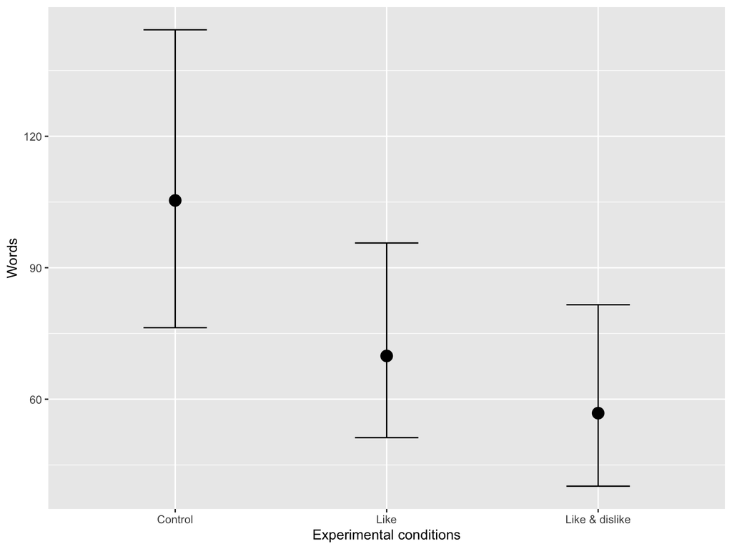

```r
run_hurdles(
  object = d,
  name = "wrds_ctrl",
  outcome = "words",
  predictor = "version",
  y_lab = "Words",
  x_lab = "Experimental conditions"
  )
```

Let’s find out by how much people in the like and like plus dislike conditions wrote fewer words.

```r
words_m_ctrl   <- fig_wrds_ctrl$data %>% filter(effect1__ == "Control") %>% pull(estimate__)
words_m_lk     <- fig_wrds_ctrl$data %>% filter(effect1__ == "Like") %>% pull(estimate__)
words_m_lkdslk <- fig_wrds_ctrl$data %>% filter(effect1__ == "Like & dislike") %>% pull(estimate__)

effect_lk_prcnt    <- round((words_m_ctrl - words_m_lk) / words_m_ctrl * 100)
effect_lkdlk_prcnt <- round((words_m_ctrl - words_m_lkdslk) / words_m_ctrl * 100)
```

Compared to the control condition, participants wrote 46 percent fewer words on the platform with likes and dislikes, and 34 percent fewer words on the platform with likes only.

We then compare the likes and control conditions to the likes plus dislikes condition.

```
Some PIT values larger than 1! Largest:  1
Rounding PIT > 1 to 1.
```

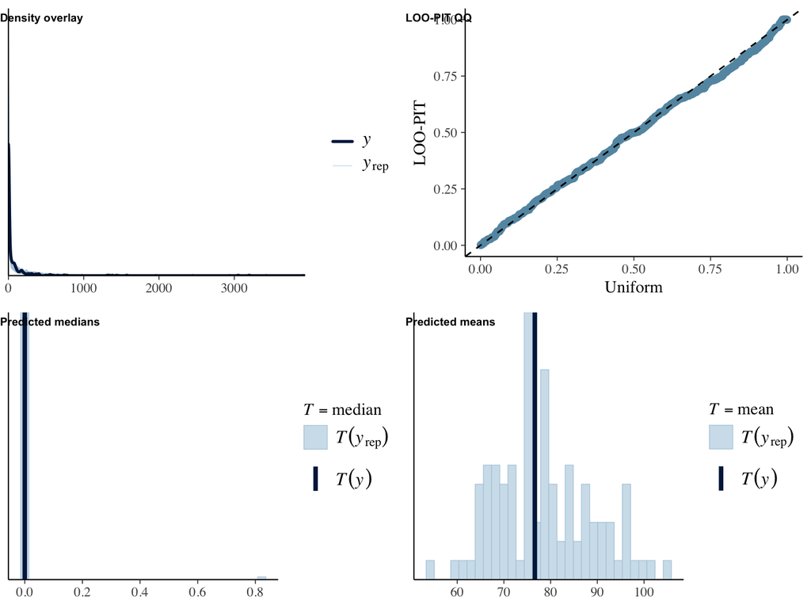

```
 Family: hurdle_gamma
  Links: mu = log; hu = logit
Formula: words ~ 1 + age + male + edu + version_lkdslk
         hu ~ 1 + age + male + edu + version_lkdslk
   Data: object (Number of observations: 558)
  Draws: 4 chains, each with iter = 1000; warmup = 500; thin = 1;
         total post-warmup draws = 2000

Regression Coefficients:
                         Estimate Est.Error l-95% CI u-95% CI Rhat Bulk_ESS Tail_ESS
Intercept                    5.15      0.36     4.47     5.86 1.00     4000     1759
hu_Intercept                 1.30      0.37     0.58     2.02 1.00     3773     1672
age                         -0.00      0.01    -0.01     0.01 1.00     4259     1796
male                        -0.18      0.16    -0.50     0.13 1.00     2721     1418
edu                          0.01      0.09    -0.17     0.20 1.00     3517     1622
version_lkdslkLike           0.08      0.21    -0.33     0.48 1.00     2436     1615
version_lkdslkControl        0.47      0.20     0.06     0.86 1.00     2077     1763
hu_age                      -0.01      0.01    -0.02     0.00 1.00     5061     1450
hu_male                     -0.06      0.17    -0.41     0.29 1.00     2997     1330
hu_edu                      -0.21      0.11    -0.42     0.01 1.00     3168     1547
hu_version_lkdslkLike       -0.22      0.21    -0.64     0.19 1.00     1957     1526
hu_version_lkdslkControl    -0.24      0.22    -0.67     0.19 1.00     2559     1715

Further Distributional Parameters:
      Estimate Est.Error l-95% CI u-95% CI Rhat Bulk_ESS Tail_ESS
shape     0.70      0.06     0.59     0.81 1.00     3295     1303

Draws were sampled using sampling(NUTS). For each parameter, Bulk_ESS
and Tail_ESS are effective sample size measures, and Rhat is the potential
scale reduction factor on split chains (at convergence, Rhat = 1).
```

```
Results of marginal effects:
  Outcome           term                 contrast estimate conf.low conf.high
1   words            age                    dY/dX    0.249   -0.769      1.26
2   words            edu                    dY/dX    9.875   -7.718     28.21
3   words           male                    1 - 0  -11.908  -42.025     17.36
4   words version_lkdslk Control - Like & dislike   48.250    9.766     89.88
5   words version_lkdslk    Like - Like & dislike   13.430  -17.925     44.17
```

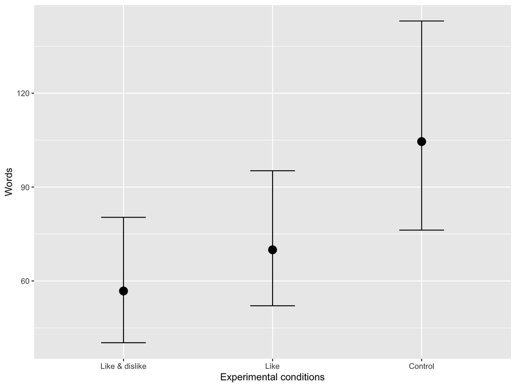

```r
run_hurdles(
  object = d,
  name = "wrds_lkdslk",
  outcome = "words",
  predictor = "version_lkdslk",
  y_lab = "Words",
  x_lab = "Experimental conditions"
  )
```

### Privacy Concerns

```
Some PIT values larger than 1! Largest:  1
Rounding PIT > 1 to 1.
```

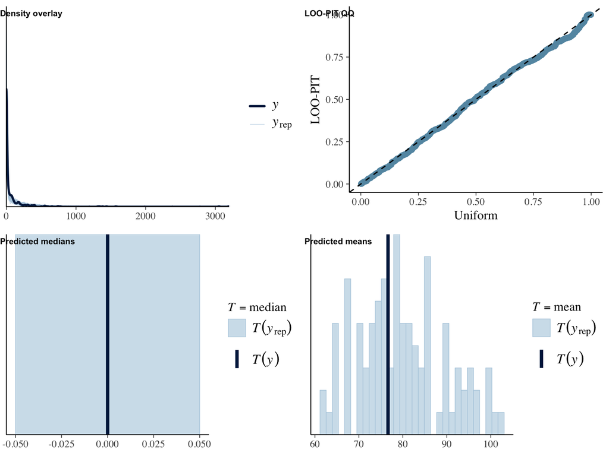

```
 Family: hurdle_gamma
  Links: mu = log; hu = logit
Formula: words ~ 1 + age + male + edu + pri_con_z
         hu ~ 1 + age + male + edu + pri_con_z
   Data: object (Number of observations: 558)
  Draws: 4 chains, each with iter = 1000; warmup = 500; thin = 1;
         total post-warmup draws = 2000

Regression Coefficients:
             Estimate Est.Error l-95% CI u-95% CI Rhat Bulk_ESS Tail_ESS
Intercept        5.34      0.36     4.66     6.04 1.00     3402     1709
hu_Intercept     1.14      0.34     0.46     1.81 1.00     3441     1723
age             -0.00      0.01    -0.01     0.01 1.00     3102     1899
male            -0.08      0.17    -0.39     0.25 1.00     3698     1679
edu             -0.01      0.09    -0.19     0.18 1.00     3740     1645
pri_con_z       -0.15      0.09    -0.32     0.02 1.00     3655     1865
hu_age          -0.01      0.01    -0.02     0.00 1.00     3501     1617
hu_male         -0.04      0.17    -0.38     0.30 1.00     3208     1626
hu_edu          -0.23      0.10    -0.44    -0.03 1.00     3643     1462
hu_pri_con_z     0.29      0.09     0.11     0.47 1.00     2701     1497

Further Distributional Parameters:
      Estimate Est.Error l-95% CI u-95% CI Rhat Bulk_ESS Tail_ESS
shape     0.69      0.05     0.59     0.80 1.00     3703     1584

Draws were sampled using sampling(NUTS). For each parameter, Bulk_ESS
and Tail_ESS are effective sample size measures, and Rhat is the potential
scale reduction factor on split chains (at convergence, Rhat = 1).
```

```
Results of marginal effects:
  Outcome      term contrast estimate conf.low conf.high
1   words       age    dY/dX    0.185   -0.877      1.18
2   words       edu    dY/dX    9.135   -7.770     26.08
3   words      male    1 - 0   -4.500  -35.323     25.08
4   words pri_con_z    dY/dX  -24.318  -41.035     -9.09
```

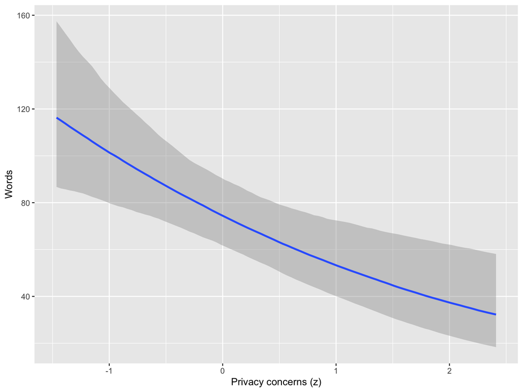

```r
run_hurdles(
  object = d,
  name = "wrds_pricon",
  outcome = "words",
  predictor = "pri_con_z",
  y_lab = "Words",
  x_lab = "Privacy concerns (z)"
  )
```

Let’s explore how the number of communicated words differs between people with the lowest and the highest privacy concerns in our sample.

```r
wrds_pricon_1 <- fig_wrds_pricon$data %>% filter(pri_con_z == min(pri_con_z)) %>% pull(estimate__) %>% round(0)
wrds_pricon_7 <- fig_wrds_pricon$data %>% filter(pri_con_z == max(pri_con_z)) %>% pull(estimate__) %>% round(0)
```

People with the lowest privacy concerns communicated on average 116 words, whereas people with the highest privacy concerns communicated on average 32 words.

### Gratifications General

```
Some PIT values larger than 1! Largest:  1
Rounding PIT > 1 to 1.
```

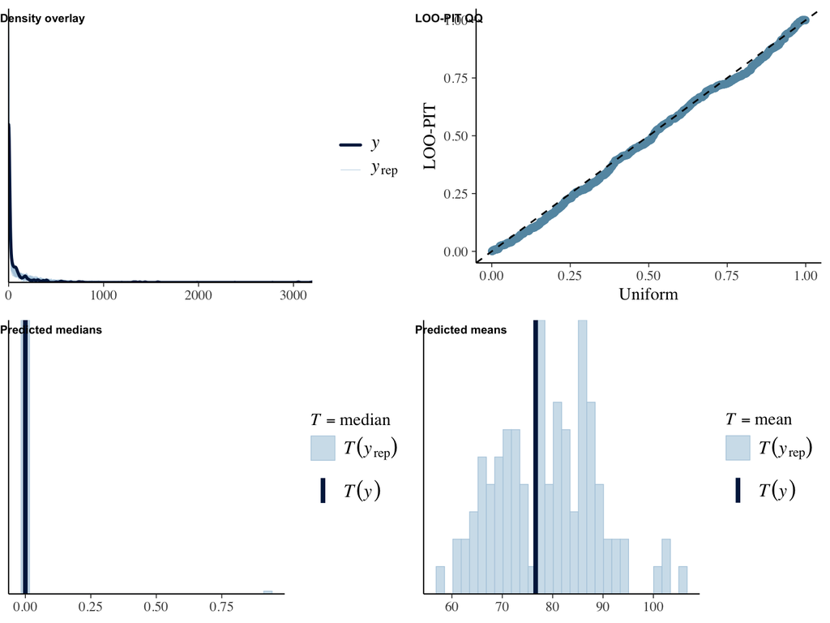

```
 Family: hurdle_gamma
  Links: mu = log; hu = logit
Formula: words ~ 1 + age + male + edu + grats_gen_z
         hu ~ 1 + age + male + edu + grats_gen_z
   Data: object (Number of observations: 558)
  Draws: 4 chains, each with iter = 1000; warmup = 500; thin = 1;
         total post-warmup draws = 2000

Regression Coefficients:
               Estimate Est.Error l-95% CI u-95% CI Rhat Bulk_ESS Tail_ESS
Intercept          5.31      0.34     4.66     6.00 1.00     3056     1415
hu_Intercept       1.19      0.35     0.50     1.87 1.00     3349     1676
age               -0.00      0.01    -0.02     0.01 1.00     3607     1513
male              -0.08      0.16    -0.40     0.24 1.00     3887     1462
edu                0.03      0.09    -0.14     0.22 1.01     2941     1343
grats_gen_z        0.25      0.08     0.09     0.41 1.00     3575     1568
hu_age            -0.01      0.01    -0.02     0.00 1.00     2916     1343
hu_male           -0.09      0.19    -0.46     0.30 1.00     4012     1502
hu_edu            -0.22      0.10    -0.42    -0.04 1.00     3397     1628
hu_grats_gen_z    -0.26      0.09    -0.44    -0.09 1.00     4026     1465

Further Distributional Parameters:
      Estimate Est.Error l-95% CI u-95% CI Rhat Bulk_ESS Tail_ESS
shape     0.70      0.06     0.60     0.82 1.00     4065     1398

Draws were sampled using sampling(NUTS). For each parameter, Bulk_ESS
and Tail_ESS are effective sample size measures, and Rhat is the potential
scale reduction factor on split chains (at convergence, Rhat = 1).
```

```
Results of marginal effects:
  Outcome        term contrast estimate conf.low conf.high
1   words         age    dY/dX   0.0609   -0.994       1.1
2   words         edu    dY/dX  12.1941   -4.372      30.8
3   words grats_gen_z    dY/dX  30.4087   15.644      49.0
4   words        male    1 - 0  -2.2613  -32.575      27.6
```

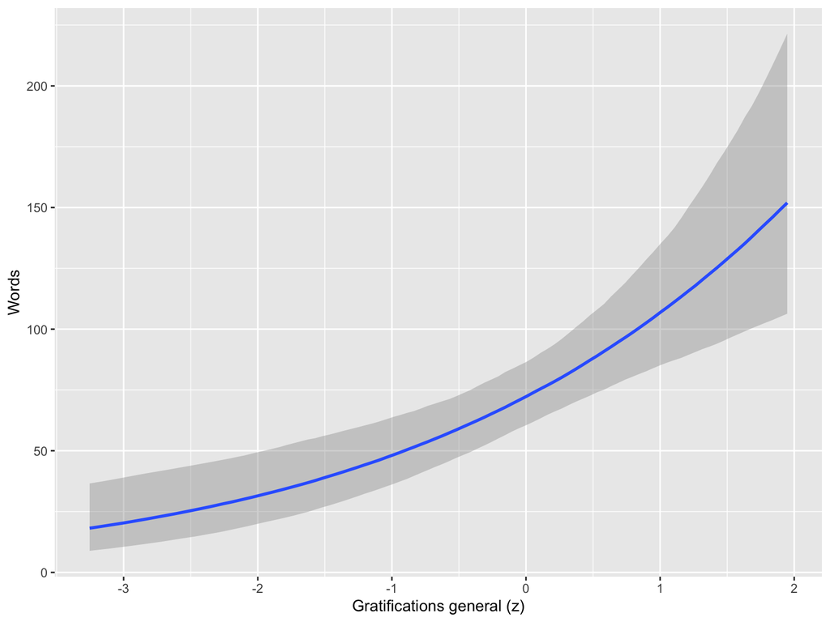

```r
run_hurdles(
  object = d,
  name = "wrds_grats",
  outcome = "words",
  predictor = "grats_gen_z",
  y_lab = "Words",
  x_lab = "Gratifications general (z)"
  )
```

### Privacy Deliberation

```
Some PIT values larger than 1! Largest:  1
Rounding PIT > 1 to 1.
```

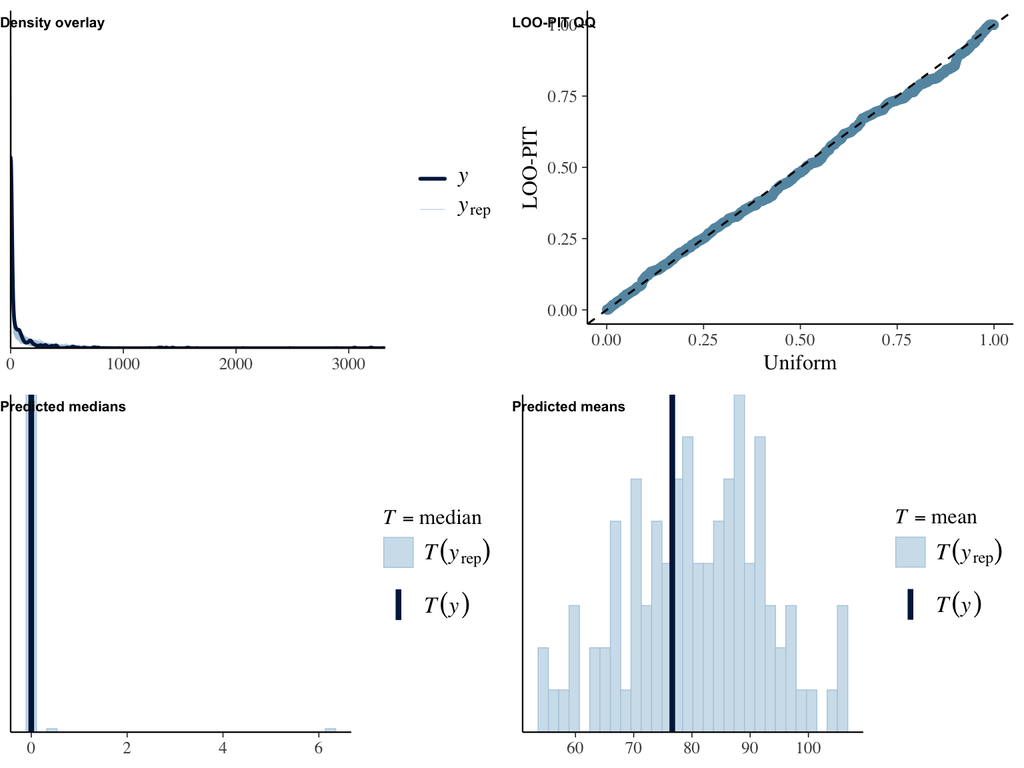

```
 Family: hurdle_gamma
  Links: mu = log; hu = logit
Formula: words ~ 1 + age + male + edu + pri_del_z
         hu ~ 1 + age + male + edu + pri_del_z
   Data: object (Number of observations: 558)
  Draws: 4 chains, each with iter = 1000; warmup = 500; thin = 1;
         total post-warmup draws = 2000

Regression Coefficients:
             Estimate Est.Error l-95% CI u-95% CI Rhat Bulk_ESS Tail_ESS
Intercept        5.47      0.37     4.75     6.21 1.00     3668     1683
hu_Intercept     1.04      0.37     0.32     1.74 1.00     3981     1649
age             -0.01      0.01    -0.02     0.01 1.00     3723     1616
male            -0.08      0.16    -0.40     0.23 1.00     4233     1523
edu             -0.02      0.09    -0.20     0.16 1.00     3272     1470
pri_del_z       -0.29      0.08    -0.45    -0.13 1.00     3272     1399
hu_age          -0.01      0.01    -0.02     0.00 1.00     3322     1478
hu_male         -0.01      0.17    -0.35     0.32 1.00     3259     1701
hu_edu          -0.22      0.11    -0.44    -0.00 1.00     4724     1377
hu_pri_del_z     0.34      0.09     0.17     0.51 1.00     3258     1451

Further Distributional Parameters:
      Estimate Est.Error l-95% CI u-95% CI Rhat Bulk_ESS Tail_ESS
shape     0.71      0.06     0.61     0.83 1.00     3034     1498

Draws were sampled using sampling(NUTS). For each parameter, Bulk_ESS
and Tail_ESS are effective sample size measures, and Rhat is the potential
scale reduction factor on split chains (at convergence, Rhat = 1).
```

```
Results of marginal effects:
  Outcome      term contrast estimate conf.low conf.high
1   words       age    dY/dX   -0.169    -1.31     0.872
2   words       edu    dY/dX    7.360    -9.25    24.940
3   words      male    1 - 0   -6.091   -35.80    23.281
4   words pri_del_z    dY/dX  -36.795   -56.04   -21.560
```

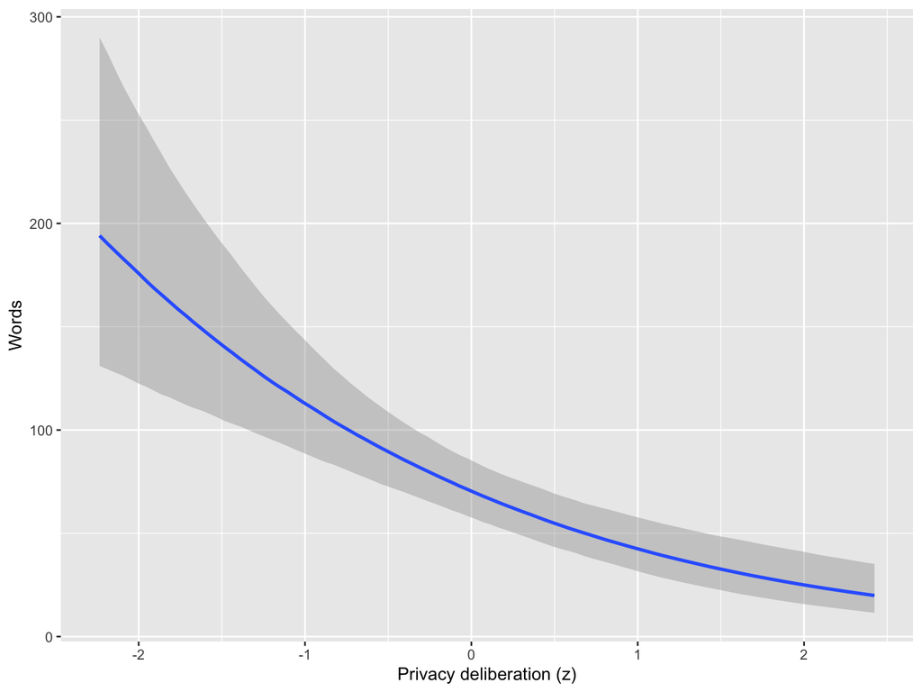

```r
run_hurdles(
  object = d,
  name = "wrds_pridel",
  outcome = "words",
  predictor = "pri_del_z",
  y_lab = "Words",
  x_lab = "Privacy deliberation (z)"
  )
```

### Trust General

```
Some PIT values larger than 1! Largest:  1
Rounding PIT > 1 to 1.
```

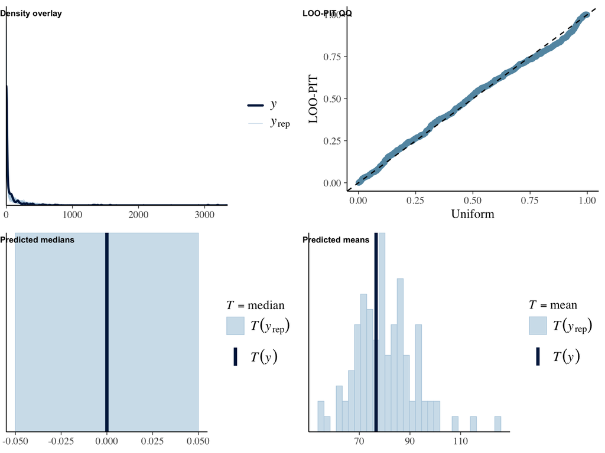

```
 Family: hurdle_gamma
  Links: mu = log; hu = logit
Formula: words ~ 1 + age + male + edu + trust_gen_z
         hu ~ 1 + age + male + edu + trust_gen_z
   Data: object (Number of observations: 558)
  Draws: 4 chains, each with iter = 1000; warmup = 500; thin = 1;
         total post-warmup draws = 2000

Regression Coefficients:
               Estimate Est.Error l-95% CI u-95% CI Rhat Bulk_ESS Tail_ESS
Intercept          5.32      0.34     4.65     6.02 1.00     4042     1738
hu_Intercept       1.25      0.35     0.57     1.94 1.00     4216     1477
age               -0.00      0.01    -0.01     0.01 1.00     3373     1534
male              -0.07      0.16    -0.40     0.25 1.00     4073     1139
edu               -0.01      0.09    -0.19     0.17 1.00     4110     1660
trust_gen_z        0.20      0.09     0.01     0.38 1.00     4064     1389
hu_age            -0.01      0.01    -0.02     0.00 1.00     3817     1422
hu_male           -0.07      0.18    -0.43     0.29 1.00     4093     1761
hu_edu            -0.22      0.10    -0.43    -0.01 1.00     3836     1560
hu_trust_gen_z    -0.34      0.09    -0.52    -0.16 1.00     3722     1329

Further Distributional Parameters:
      Estimate Est.Error l-95% CI u-95% CI Rhat Bulk_ESS Tail_ESS
shape     0.70      0.05     0.59     0.81 1.00     4394     1610

Draws were sampled using sampling(NUTS). For each parameter, Bulk_ESS
and Tail_ESS are effective sample size measures, and Rhat is the potential
scale reduction factor on split chains (at convergence, Rhat = 1).
```

```
Results of marginal effects:
  Outcome        term contrast estimate conf.low conf.high
1   words         age    dY/dX    0.277   -0.773       1.3
2   words         edu    dY/dX    8.403   -8.233      24.9
3   words        male    1 - 0   -2.632  -32.189      29.4
4   words trust_gen_z    dY/dX   29.687   14.109      49.6
```

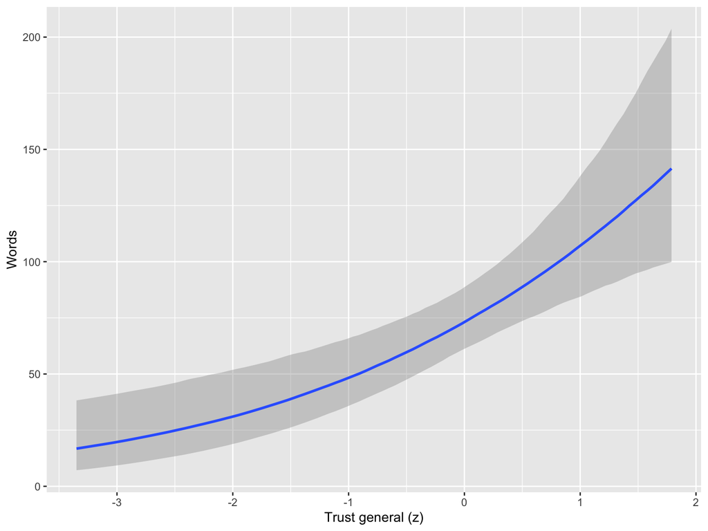

```r
run_hurdles(
  object = d,
  name = "wrds_trust",
  outcome = "words",
  predictor = "trust_gen_z",
  y_lab = "Words",
  x_lab = "Trust general (z)"
  )
```

### Self-Efficacy

```
Some PIT values larger than 1! Largest:  1
Rounding PIT > 1 to 1.
```

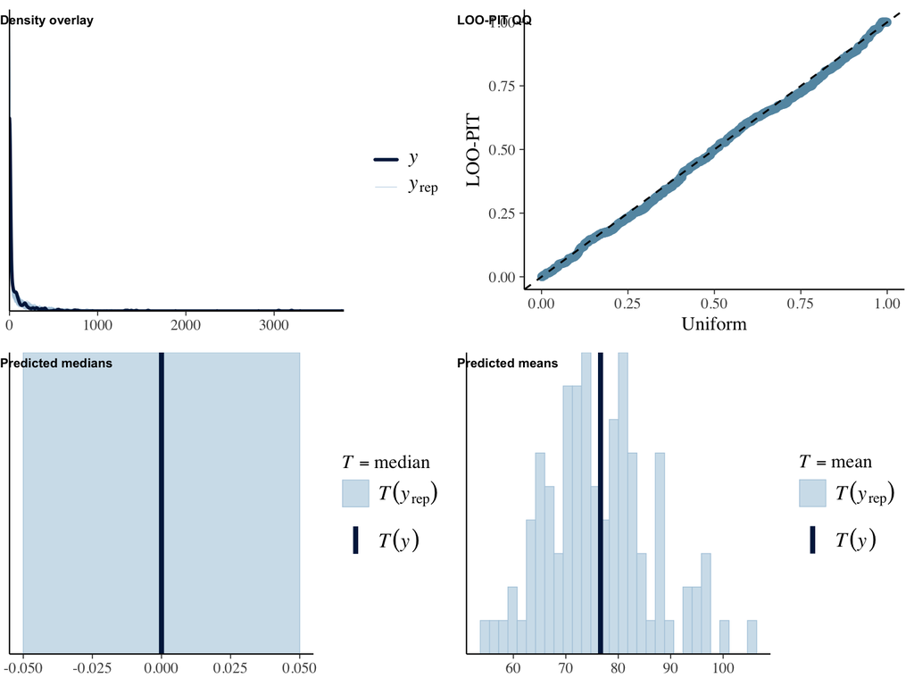

```
 Family: hurdle_gamma
  Links: mu = log; hu = logit
Formula: words ~ 1 + age + male + edu + self_eff_z
         hu ~ 1 + age + male + edu + self_eff_z
   Data: object (Number of observations: 558)
  Draws: 4 chains, each with iter = 1000; warmup = 500; thin = 1;
         total post-warmup draws = 2000

Regression Coefficients:
              Estimate Est.Error l-95% CI u-95% CI Rhat Bulk_ESS Tail_ESS
Intercept         5.23      0.32     4.62     5.87 1.00     3941     1820
hu_Intercept      1.11      0.39     0.37     1.91 1.00     4660     1494
age              -0.00      0.01    -0.01     0.01 1.00     3726     1590
male             -0.16      0.15    -0.47     0.15 1.00     4369     1492
edu              -0.06      0.08    -0.22     0.10 1.00     3618     1679
self_eff_z        0.56      0.07     0.41     0.70 1.00     2745     1629
hu_age           -0.01      0.01    -0.02     0.00 1.00     5764     1395
hu_male          -0.01      0.20    -0.37     0.38 1.00     5121     1406
hu_edu           -0.13      0.11    -0.34     0.10 1.00     4246     1565
hu_self_eff_z    -0.85      0.11    -1.06    -0.65 1.00     4013     1261

Further Distributional Parameters:
      Estimate Est.Error l-95% CI u-95% CI Rhat Bulk_ESS Tail_ESS
shape     0.80      0.07     0.67     0.94 1.01     5618     1300

Draws were sampled using sampling(NUTS). For each parameter, Bulk_ESS
and Tail_ESS are effective sample size measures, and Rhat is the potential
scale reduction factor on split chains (at convergence, Rhat = 1).
```

```
Results of marginal effects:
  Outcome       term contrast estimate conf.low conf.high
1   words        age    dY/dX    0.038   -0.859      0.91
2   words        edu    dY/dX   -0.869  -15.751     13.35
3   words       male    1 - 0  -11.934  -39.449     14.24
4   words self_eff_z    dY/dX   70.272   53.054     91.83
```

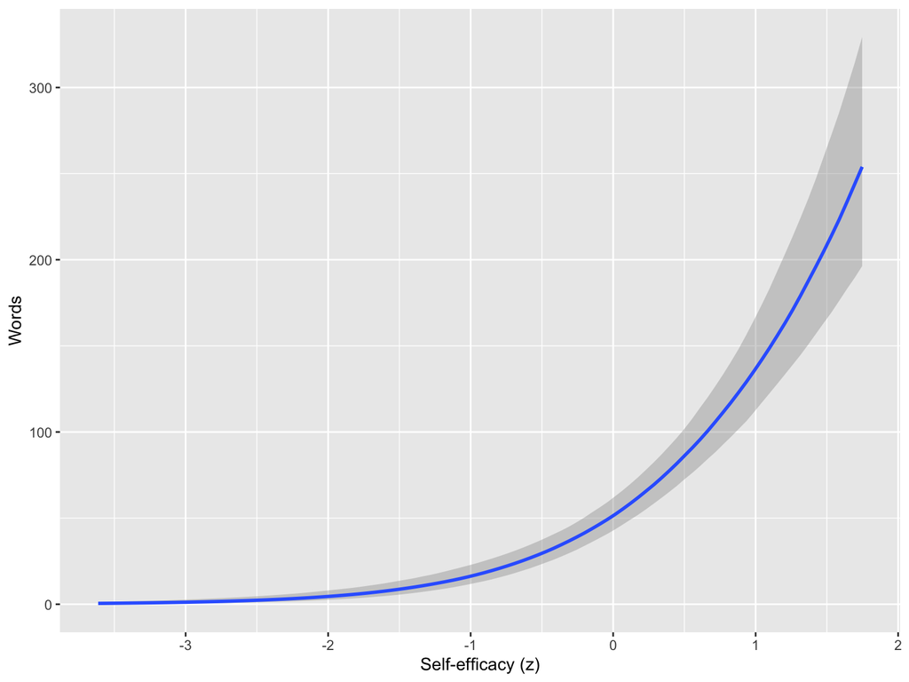

```r
run_hurdles(
  object = d,
  name = "wrds_selfeff",
  outcome = "words",
  predictor = "self_eff_z",
  y_lab = "Words",
  x_lab = "Self-efficacy (z)"
  )
```

The relation is markedly exponential. Let’s inspect how the number of words changes with a one-SD increase in self-efficacy, once starting from the lowest level of self-efficacy in our sample, and once ending at the highest level.

```r
self_eff_lo <- min(d$self_eff_z)       # lowest observed self-efficacy
self_eff_hi <- max(d$self_eff_z) - 1   # one SD below the highest observed self-efficacy

# average change in the expected number of words for a one-SD increase,
# evaluated for all participants at the given level of self-efficacy (counterfactual grid)
effects_wrds_selfeff_12 <-
  avg_comparisons(
    fit_wrds_selfeff,
    variables = list(self_eff_z = 1),
    newdata = datagrid(self_eff_z = self_eff_lo, grid_type = "counterfactual")
    ) %>%
  pull(estimate) %>%
  round(0)

effects_wrds_selfeff_67 <-
  avg_comparisons(
    fit_wrds_selfeff,
    variables = list(self_eff_z = 1),
    newdata = datagrid(self_eff_z = self_eff_hi, grid_type = "counterfactual")
    ) %>%
  pull(estimate) %>%
  round(0)
```

Starting from the lowest level of self-efficacy, an increase of one standard deviation was associated with 2 more words; ending at the highest level, the same increase was associated with 146 more words.

Let’s explore how the number of communicated words differs between people with the lowest and the highest self-efficacy in our sample.

```r
wrds_selfeff_1 <- fig_wrds_selfeff$data %>% filter(self_eff_z == min(self_eff_z)) %>% pull(estimate__) %>% round(0)
wrds_selfeff_7 <- fig_wrds_selfeff$data %>% filter(self_eff_z == max(self_eff_z)) %>% pull(estimate__) %>% round(0)
```

People with the lowest self-efficacy communicated on average 1 words, whereas people with the highest self-efficacy communicated on average 254 words.

### Visualization

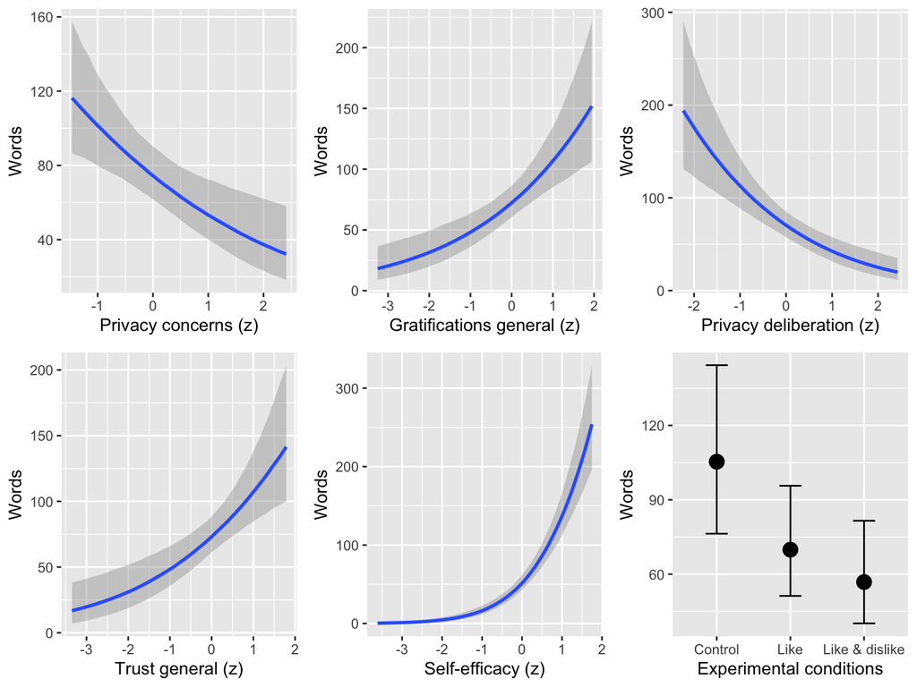

```r
fig_results <-
  plot_grid(
    fig_wrds_pricon,
    fig_wrds_grats,
    fig_wrds_pridel,
    fig_wrds_trust,
    fig_wrds_selfeff,
    fig_wrds_ctrl
    ) %T>%
  print()
```

```r
ggsave("figures/results/effects.pdf", fig_results, width = 8, height = 8)
ggsave("figures/results/effects.png", fig_results, width = 8, height = 8)
```

### Table

Table of the average marginal effects (words: rounded to whole words).

```r
# helper: turn the slopes of several hurdle models into one table
label_slopes <- function(slopes_list) {

  predictors <- c(
    "pri_con_z"    = "Privacy concerns",
    "pri_del_z"    = "Privacy deliberation",
    "grats_gen_z"  = "Expected gratifications",
    "trust_gen_z"  = "Trust",
    "self_eff_z"   = "Self-efficacy",
    "Like - Control"           = "Like vs. control",
    "Like & dislike - Control" = "Like & dislike vs. control",
    "Like - Like & dislike"    = "Like vs. like & dislike"
    )

  outcomes <- c(
    "pri_con_fs"   = "Privacy concerns",
    "pri_del_fs"   = "Privacy deliberation",
    "grats_gen_fs" = "Expected gratifications",
    "trust_gen_fs" = "Trust",
    "self_eff_fs"  = "Self-efficacy"
    )

  slopes_list %>%
    map(as.data.frame) %>%
    bind_rows() %>%
    mutate(
      # for the experimental factors, the contrast identifies the comparison
      term = if_else(
        contrast %in% c("Like - Control", "Like & dislike - Control", "Like - Like & dislike"),
        contrast,
        term
        )
      ) %>%
    filter(term %in% names(predictors)) %>%   # drops the covariates and the duplicated contrast
    mutate(
      Predictor = factor(
        predictors[term],
        levels = c("Self-efficacy", "Trust", "Privacy deliberation", "Expected gratifications",
                   "Privacy concerns", "Like vs. like & dislike", "Like & dislike vs. control",
                   "Like vs. control")
        ),
      Outcome   = recode(Outcome, !!!outcomes),
      Estimate  = if_else(Outcome == "words", round(estimate), estimate),
      LL        = if_else(Outcome == "words", round(conf.low), conf.low),
      UL        = if_else(Outcome == "words", round(conf.high), conf.high)
      ) %>%
    select(Outcome, Predictor, Estimate, LL, UL)
}

tab_slopes <-
  label_slopes(
    list(
      slopes_wrds_pricon,
      slopes_wrds_grats,
      slopes_wrds_pridel,
      slopes_wrds_trust,
      slopes_wrds_selfeff,
      slopes_wrds_ctrl,
      slopes_wrds_lkdslk,
      slopes_pricon_ctrl,
      slopes_pricon_lkdslk,
      slopes_grats_ctrl,
      slopes_grats_lkdslk,
      slopes_pridel_ctrl,
      slopes_pridel_lkdslk,
      slopes_trust_ctrl,
      slopes_trust_lkdslk,
      slopes_selfeff_ctrl,
      slopes_selfeff_lkdslk
      )
    )

tab_slopes %>%
  kable(digits = 2) %>%
  kable_styling("striped") %>%
  scroll_box(width = "100%")
```

| Outcome | Predictor | Estimate | LL | UL |
| --- | --- | --- | --- | --- |
| words | Privacy concerns | -24.00 | -41.00 | -9.00 |
| words | Expected gratifications | 30.00 | 16.00 | 49.00 |
| words | Privacy deliberation | -37.00 | -56.00 | -22.00 |
| words | Trust | 30.00 | 14.00 | 50.00 |
| words | Self-efficacy | 70.00 | 53.00 | 92.00 |
| words | Like & dislike vs. control | -48.00 | -90.00 | -11.00 |
| words | Like vs. control | -36.00 | -78.00 | 2.00 |
| words | Like vs. like & dislike | 13.00 | -18.00 | 44.00 |
| Privacy concerns | Like & dislike vs. control | 0.17 | -0.15 | 0.51 |
| Privacy concerns | Like vs. control | 0.03 | -0.29 | 0.36 |
| Privacy concerns | Like vs. like & dislike | -0.16 | -0.50 | 0.18 |
| Expected gratifications | Like & dislike vs. control | -0.21 | -0.47 | 0.06 |
| Expected gratifications | Like vs. control | -0.17 | -0.42 | 0.08 |
| Expected gratifications | Like vs. like & dislike | 0.03 | -0.21 | 0.30 |
| Privacy deliberation | Like & dislike vs. control | -0.04 | -0.29 | 0.20 |
| Privacy deliberation | Like vs. control | -0.01 | -0.25 | 0.23 |
| Privacy deliberation | Like vs. like & dislike | 0.03 | -0.21 | 0.27 |
| Trust | Like & dislike vs. control | -0.12 | -0.34 | 0.07 |
| Trust | Like vs. control | -0.15 | -0.34 | 0.06 |
| Trust | Like vs. like & dislike | -0.02 | -0.22 | 0.20 |
| Self-efficacy | Like & dislike vs. control | -0.09 | -0.31 | 0.12 |
| Self-efficacy | Like vs. control | -0.09 | -0.29 | 0.11 |
| Self-efficacy | Like vs. like & dislike | 0.00 | -0.21 | 0.21 |

## Self-Disclosure

How do the results change if we look at self-disclosure instead of communication only? Self-disclosure is the standardized index described above (see Measures): 0 means that someone did not disclose anything (did not comment), and all other values are expressed in standard deviations. Predictors are again standardized, so effects can be read as the change in self-disclosure (in SD) for a one-SD increase in the predictor.

### Experimental Factors

We first compare likes and likes plus dislikes to the control condition.

```
Some PIT values larger than 1! Largest:  1
Rounding PIT > 1 to 1.
```

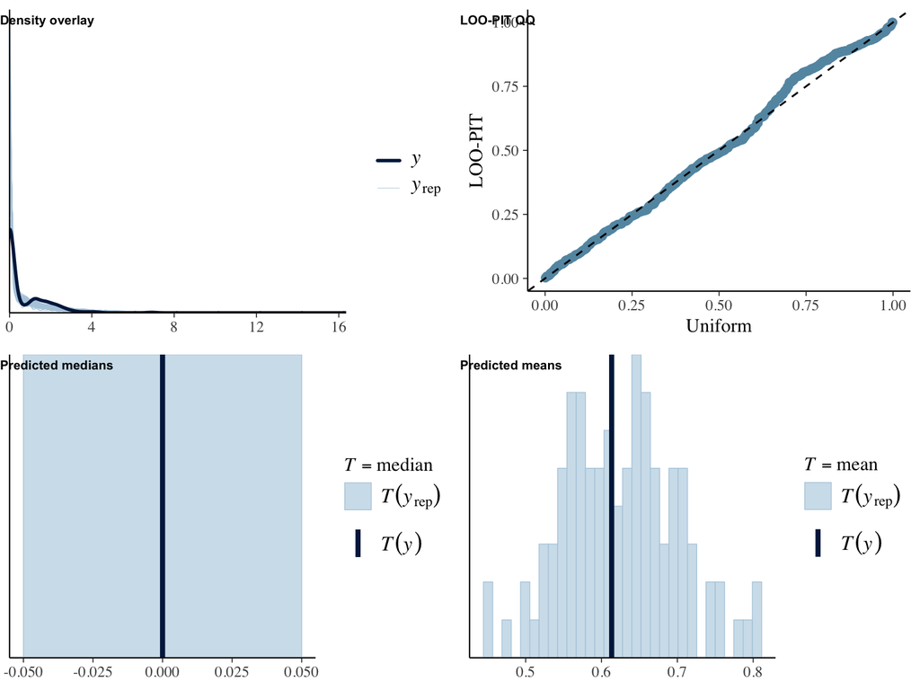

```
 Family: hurdle_gamma
  Links: mu = log; hu = logit
Formula: self_disc ~ 1 + age + male + edu + version
         hu ~ 1 + age + male + edu + version
   Data: object (Number of observations: 558)
  Draws: 4 chains, each with iter = 1000; warmup = 500; thin = 1;
         total post-warmup draws = 2000

Regression Coefficients:
                       Estimate Est.Error l-95% CI u-95% CI Rhat Bulk_ESS Tail_ESS
Intercept                  0.55      0.30    -0.02     1.14 1.00     3250     1482
hu_Intercept               1.05      0.35     0.37     1.73 1.00     3582     1770
age                       -0.00      0.00    -0.01     0.01 1.00     2652     1386
male                      -0.00      0.14    -0.25     0.26 1.00     3913     1649
edu                       -0.02      0.08    -0.19     0.14 1.01     3866     1474
versionLike               -0.12      0.16    -0.44     0.20 1.00     2698     1423
versionLike&dislike       -0.19      0.17    -0.53     0.13 1.00     2583     1475
hu_age                    -0.01      0.01    -0.02     0.00 1.00     5851     1565
hu_male                   -0.06      0.18    -0.40     0.29 1.00     3509     1304
hu_edu                    -0.21      0.10    -0.41    -0.01 1.00     3160     1520
hu_versionLike             0.02      0.21    -0.38     0.44 1.00     2583     1604
hu_versionLike&dislike     0.24      0.21    -0.16     0.67 1.00     2233     1568

Further Distributional Parameters:
      Estimate Est.Error l-95% CI u-95% CI Rhat Bulk_ESS Tail_ESS
shape     0.93      0.07     0.79     1.08 1.00     3229     1364

Draws were sampled using sampling(NUTS). For each parameter, Bulk_ESS
and Tail_ESS are effective sample size measures, and Rhat is the potential
scale reduction factor on split chains (at convergence, Rhat = 1).
```

```
Results of marginal effects:
    Outcome    term                 contrast estimate conf.low conf.high
1 self_disc     age                    dY/dX  0.00267 -0.00396   0.00941
2 self_disc     edu                    dY/dX  0.06056 -0.06135   0.19544
3 self_disc    male                    1 - 0  0.02186 -0.19071   0.22557
4 self_disc version Like & dislike - Control -0.19597 -0.47486   0.05281
5 self_disc version           Like - Control -0.09392 -0.36936   0.18105
```

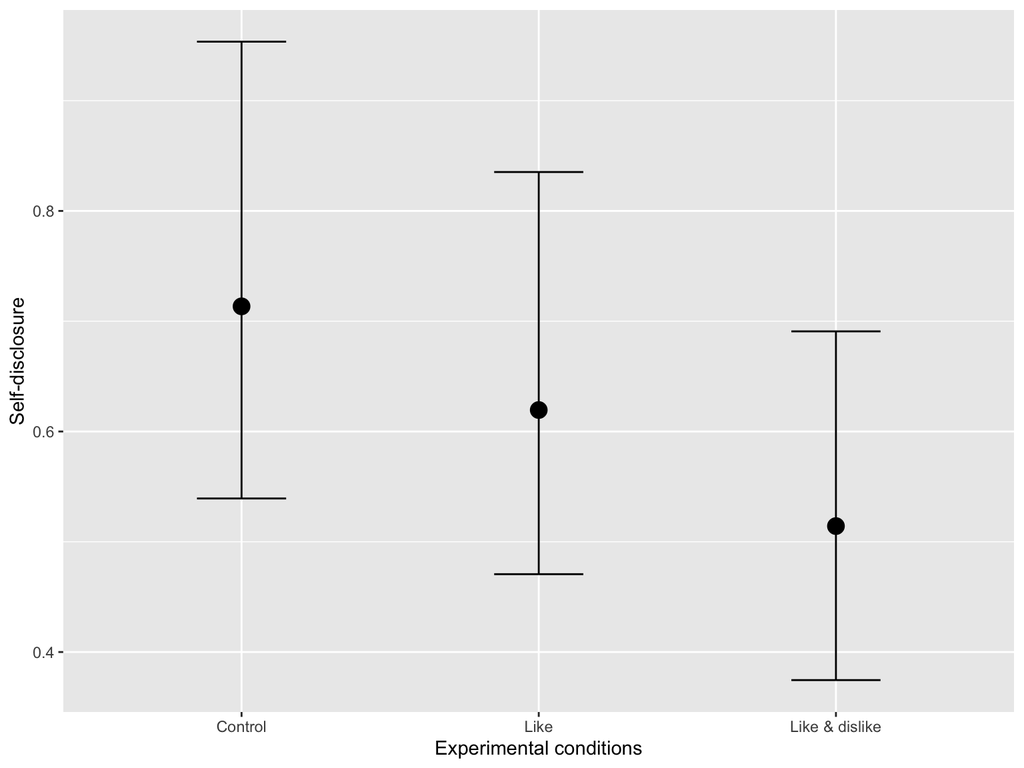

```r
run_hurdles(
  object = d,
  name = "self_disc_ctrl",
  outcome = "self_disc",
  predictor = "version",
  y_lab = "Self-disclosure",
  x_lab = "Experimental conditions"
  )
```

```r
sd_m_ctrl   <- fig_self_disc_ctrl$data %>% filter(effect1__ == "Control") %>% pull(estimate__)
sd_m_lk     <- fig_self_disc_ctrl$data %>% filter(effect1__ == "Like") %>% pull(estimate__)
sd_m_lkdslk <- fig_self_disc_ctrl$data %>% filter(effect1__ == "Like & dislike") %>% pull(estimate__)

effect_lk_prcnt_sd    <- round((sd_m_ctrl - sd_m_lk) / sd_m_ctrl * 100)
effect_lkdlk_prcnt_sd <- round((sd_m_ctrl - sd_m_lkdslk) / sd_m_ctrl * 100)
```

Compared to the control condition, self-disclosure was 28 percent lower on the platform with likes and dislikes, and 13 percent lower on the platform with likes only.

We then compare the likes and control conditions to the likes plus dislikes condition.

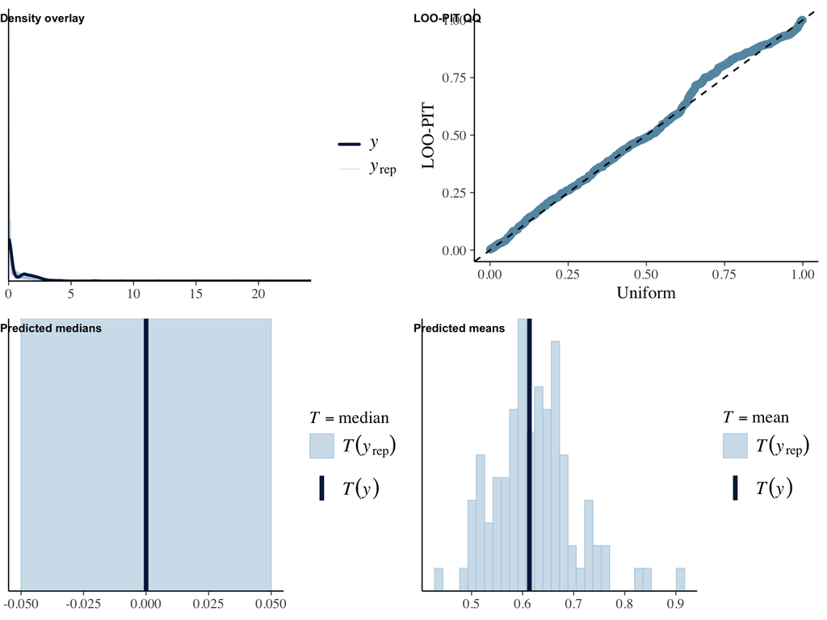

```
 Family: hurdle_gamma
  Links: mu = log; hu = logit
Formula: self_disc ~ 1 + age + male + edu + version_lkdslk
         hu ~ 1 + age + male + edu + version_lkdslk
   Data: object (Number of observations: 558)
  Draws: 4 chains, each with iter = 1000; warmup = 500; thin = 1;
         total post-warmup draws = 2000

Regression Coefficients:
                         Estimate Est.Error l-95% CI u-95% CI Rhat Bulk_ESS Tail_ESS
Intercept                    0.37      0.31    -0.23     0.98 1.00     4602     1598
hu_Intercept                 1.30      0.38     0.58     2.05 1.00     3561     1557
age                         -0.00      0.00    -0.01     0.01 1.00     4846     1668
male                        -0.01      0.13    -0.27     0.25 1.00     3903     1709
edu                         -0.02      0.08    -0.19     0.15 1.00     3870     1633
version_lkdslkLike           0.06      0.17    -0.27     0.40 1.00     2202     1606
version_lkdslkControl        0.19      0.18    -0.17     0.53 1.00     2488     1731
hu_age                      -0.01      0.01    -0.02     0.00 1.00     4214     1706
hu_male                     -0.06      0.18    -0.42     0.30 1.00     3964     1566
hu_edu                      -0.21      0.10    -0.41    -0.01 1.00     3091     1724
hu_version_lkdslkLike       -0.22      0.21    -0.63     0.21 1.00     2695     1706
hu_version_lkdslkControl    -0.24      0.22    -0.67     0.20 1.00     2709     1810

Further Distributional Parameters:
      Estimate Est.Error l-95% CI u-95% CI Rhat Bulk_ESS Tail_ESS
shape     0.93      0.08     0.78     1.08 1.00     4560     1669

Draws were sampled using sampling(NUTS). For each parameter, Bulk_ESS
and Tail_ESS are effective sample size measures, and Rhat is the potential
scale reduction factor on split chains (at convergence, Rhat = 1).
```

```
Results of marginal effects:
    Outcome           term                 contrast estimate conf.low conf.high
1 self_disc            age                    dY/dX  0.00264 -0.00484    0.0102
2 self_disc            edu                    dY/dX  0.06062 -0.06177    0.1871
3 self_disc           male                    1 - 0  0.01873 -0.18299    0.2239
4 self_disc version_lkdslk Control - Like & dislike  0.20468 -0.05736    0.4752
5 self_disc version_lkdslk    Like - Like & dislike  0.10352 -0.13865    0.3399
```

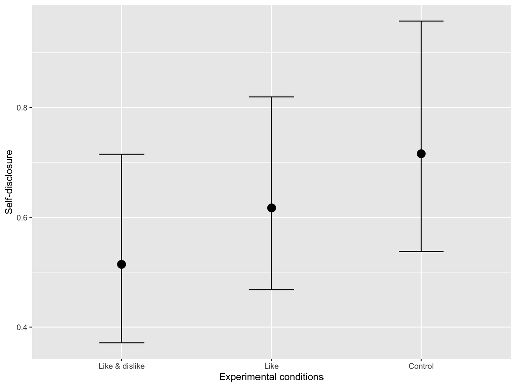

```r
run_hurdles(
  object = d,
  name = "self_disc_lkdslk",
  outcome = "self_disc",
  predictor = "version_lkdslk",
  y_lab = "Self-disclosure",
  x_lab = "Experimental conditions"
  )
```

### Privacy Concerns

```
Some PIT values larger than 1! Largest:  1
Rounding PIT > 1 to 1.
```

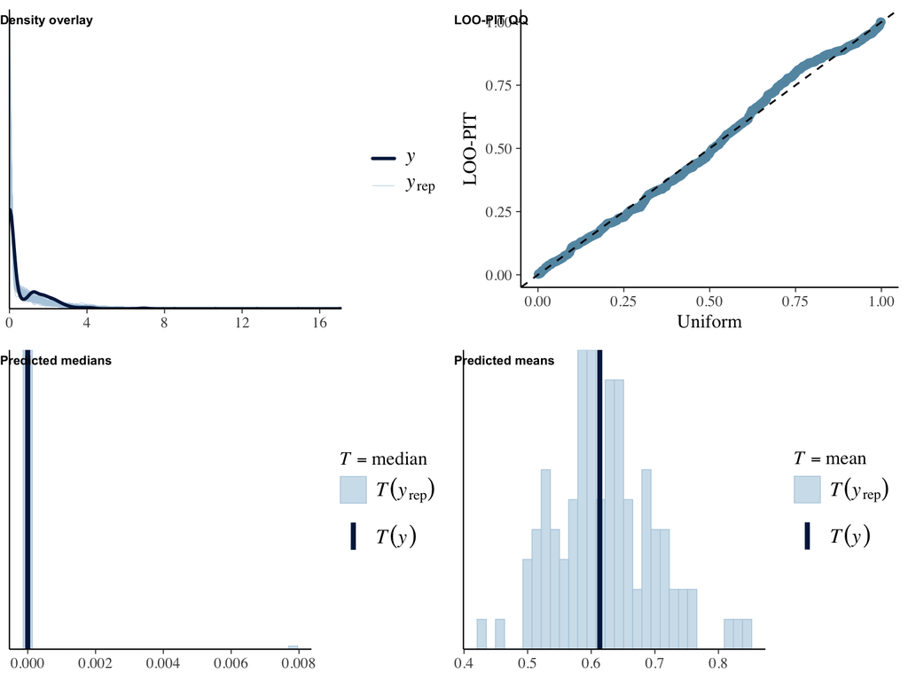

```
 Family: hurdle_gamma
  Links: mu = log; hu = logit
Formula: self_disc ~ 1 + age + male + edu + pri_con_z
         hu ~ 1 + age + male + edu + pri_con_z
   Data: object (Number of observations: 558)
  Draws: 4 chains, each with iter = 1000; warmup = 500; thin = 1;
         total post-warmup draws = 2000

Regression Coefficients:
             Estimate Est.Error l-95% CI u-95% CI Rhat Bulk_ESS Tail_ESS
Intercept        0.45      0.29    -0.12     1.02 1.00     3609     1308
hu_Intercept     1.14      0.35     0.45     1.85 1.00     3491     1686
age             -0.00      0.00    -0.01     0.01 1.00     3778     1345
male             0.01      0.14    -0.27     0.28 1.00     3194     1387
edu             -0.02      0.08    -0.19     0.14 1.00     4122     1421
pri_con_z       -0.05      0.08    -0.20     0.10 1.00     3687     1359
hu_age          -0.01      0.01    -0.02     0.00 1.00     3858     1403
hu_male         -0.04      0.18    -0.39     0.30 1.00     3039     1443
hu_edu          -0.23      0.11    -0.44    -0.02 1.00     3307     1567
hu_pri_con_z     0.29      0.09     0.12     0.46 1.00     3437     1466

Further Distributional Parameters:
      Estimate Est.Error l-95% CI u-95% CI Rhat Bulk_ESS Tail_ESS
shape     0.93      0.07     0.80     1.08 1.00     3788     1741

Draws were sampled using sampling(NUTS). For each parameter, Bulk_ESS
and Tail_ESS are effective sample size measures, and Rhat is the potential
scale reduction factor on split chains (at convergence, Rhat = 1).
```

```
Results of marginal effects:
    Outcome      term contrast estimate conf.low conf.high
1 self_disc       age    dY/dX  0.00237 -0.00462   0.00964
2 self_disc       edu    dY/dX  0.06152 -0.06171   0.19101
3 self_disc      male    1 - 0  0.02068 -0.18336   0.22485
4 self_disc pri_con_z    dY/dX -0.12829 -0.25132  -0.01812
```

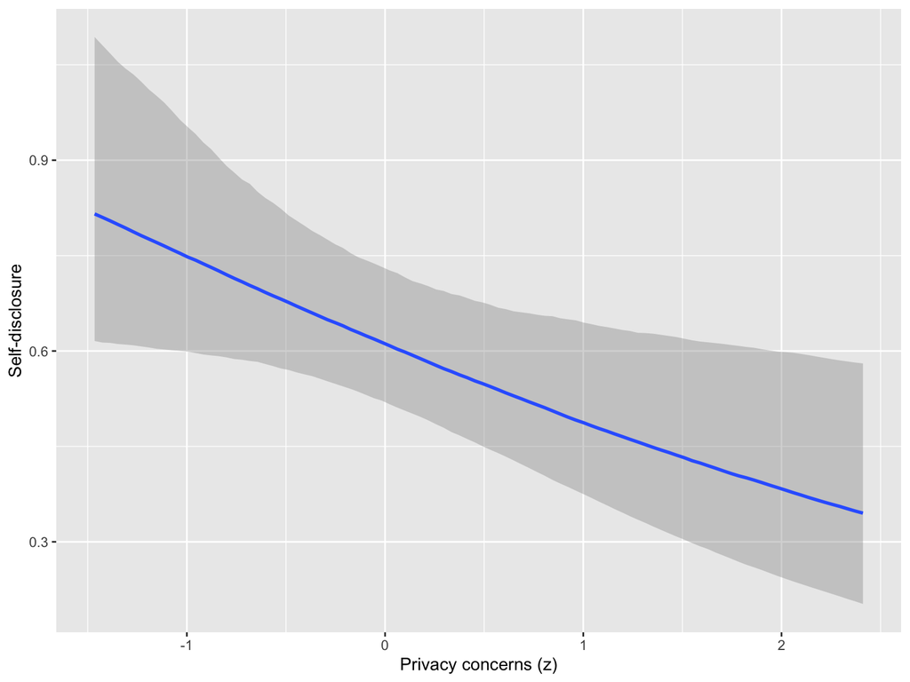

```r
run_hurdles(
  object = d,
  name = "self_disc_pricon",
  outcome = "self_disc",
  predictor = "pri_con_z",
  y_lab = "Self-disclosure",
  x_lab = "Privacy concerns (z)"
  )
```

Let’s explore how self-disclosure differs between people with the lowest and the highest privacy concerns in our sample.

```r
self_disc_pricon_1 <- fig_self_disc_pricon$data %>% filter(pri_con_z == min(pri_con_z)) %>% pull(estimate__) %>% round(2)
self_disc_pricon_7 <- fig_self_disc_pricon$data %>% filter(pri_con_z == max(pri_con_z)) %>% pull(estimate__) %>% round(2)
```

People with the lowest privacy concerns had a predicted self-disclosure of 0.82 SD, whereas people with the highest privacy concerns had 0.35 SD.

### Gratifications General

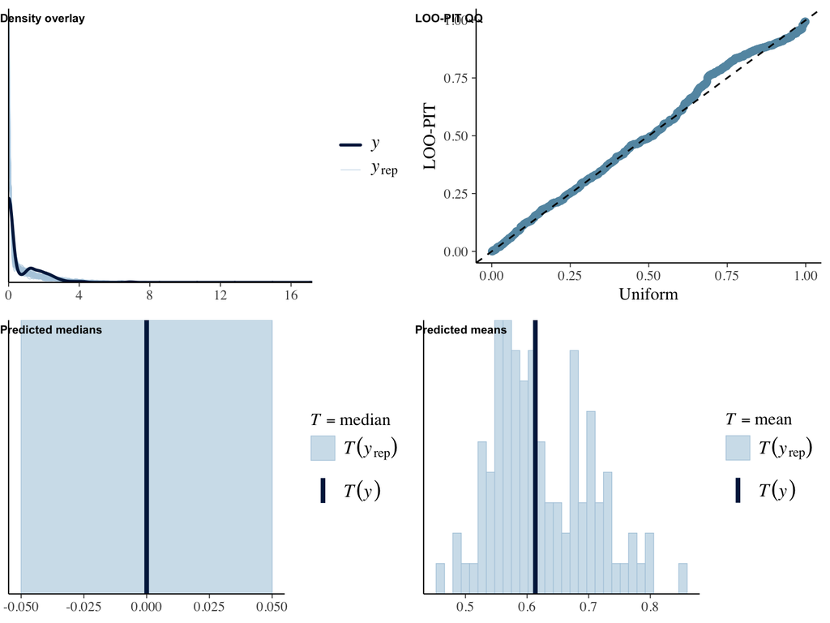

```
 Family: hurdle_gamma
  Links: mu = log; hu = logit
Formula: self_disc ~ 1 + age + male + edu + grats_gen_z
         hu ~ 1 + age + male + edu + grats_gen_z
   Data: object (Number of observations: 558)
  Draws: 4 chains, each with iter = 1000; warmup = 500; thin = 1;
         total post-warmup draws = 2000

Regression Coefficients:
               Estimate Est.Error l-95% CI u-95% CI Rhat Bulk_ESS Tail_ESS
Intercept          0.46      0.28    -0.09     1.02 1.00     3312     1561
hu_Intercept       1.19      0.36     0.49     1.89 1.00     3460     1840
age               -0.00      0.00    -0.01     0.01 1.00     4185     1750
male               0.01      0.14    -0.27     0.29 1.00     4136     1232
edu               -0.02      0.08    -0.18     0.14 1.00     3520     1753
grats_gen_z        0.01      0.07    -0.13     0.14 1.00     2953     1533
hu_age            -0.01      0.01    -0.02     0.00 1.01     3835     1611
hu_male           -0.09      0.18    -0.44     0.27 1.00     4815     1415
hu_edu            -0.22      0.10    -0.42    -0.02 1.00     3070     1478
hu_grats_gen_z    -0.26      0.09    -0.44    -0.09 1.00     3518     1425

Further Distributional Parameters:
      Estimate Est.Error l-95% CI u-95% CI Rhat Bulk_ESS Tail_ESS
shape     0.93      0.08     0.79     1.09 1.00     3864     1631

Draws were sampled using sampling(NUTS). For each parameter, Bulk_ESS
and Tail_ESS are effective sample size measures, and Rhat is the potential
scale reduction factor on split chains (at convergence, Rhat = 1).
```

```
Results of marginal effects:
    Outcome        term contrast estimate conf.low conf.high
1 self_disc         age    dY/dX  0.00252 -0.00445   0.00961
2 self_disc         edu    dY/dX  0.06552 -0.04936   0.19503
3 self_disc grats_gen_z    dY/dX  0.09430 -0.01623   0.19691
4 self_disc        male    1 - 0  0.03992 -0.17481   0.25605
```

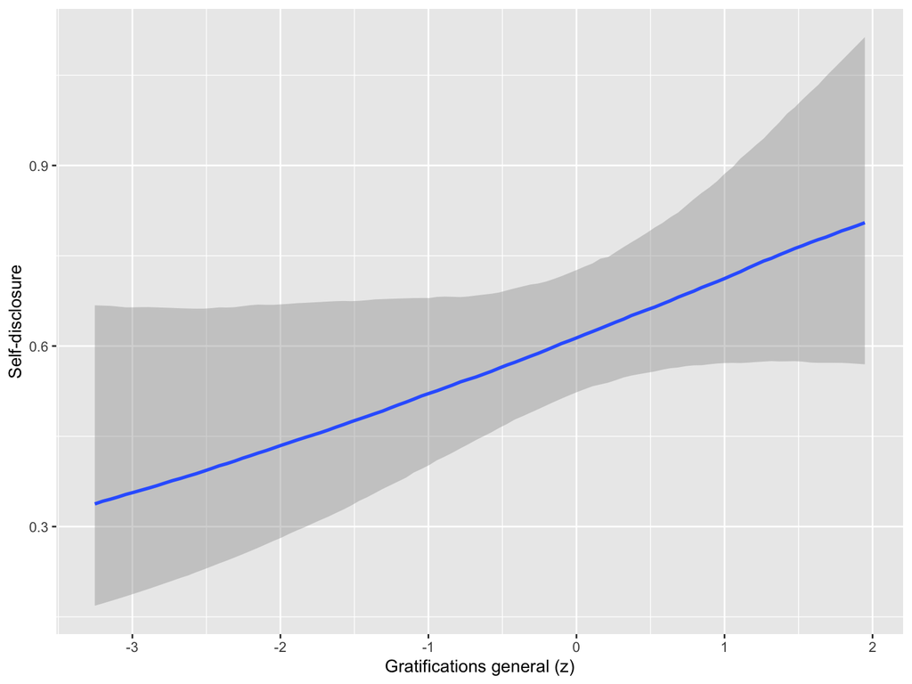

```r
run_hurdles(
  object = d,
  name = "self_disc_grats",
  outcome = "self_disc",
  predictor = "grats_gen_z",
  y_lab = "Self-disclosure",
  x_lab = "Gratifications general (z)"
  )
```

### Privacy Deliberation

```
Some PIT values larger than 1! Largest:  1
Rounding PIT > 1 to 1.
```

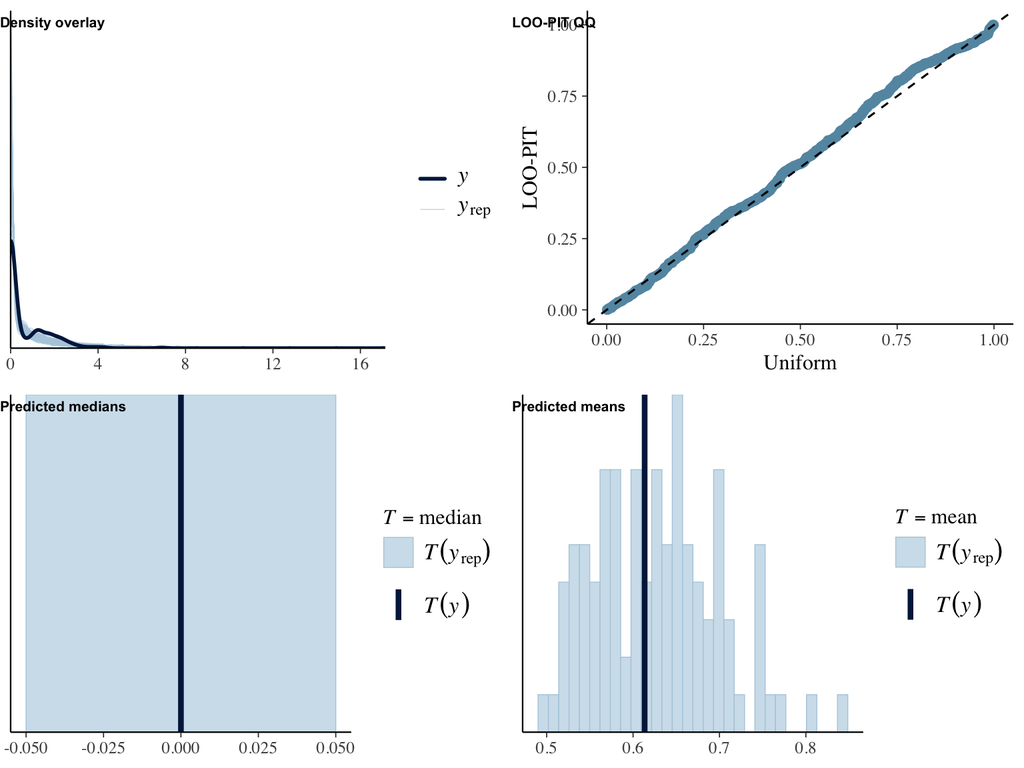

```
 Family: hurdle_gamma
  Links: mu = log; hu = logit
Formula: self_disc ~ 1 + age + male + edu + pri_del_z
         hu ~ 1 + age + male + edu + pri_del_z
   Data: object (Number of observations: 558)
  Draws: 4 chains, each with iter = 1000; warmup = 500; thin = 1;
         total post-warmup draws = 2000

Regression Coefficients:
             Estimate Est.Error l-95% CI u-95% CI Rhat Bulk_ESS Tail_ESS
Intercept        0.48      0.29    -0.06     1.06 1.00     4297     1890
hu_Intercept     1.04      0.36     0.37     1.77 1.00     4541     1243
age             -0.00      0.00    -0.01     0.01 1.00     4169     1757
male            -0.01      0.14    -0.27     0.28 1.00     3256     1379
edu             -0.03      0.08    -0.19     0.13 1.00     3008     1594
pri_del_z       -0.12      0.07    -0.25     0.01 1.00     3559     1368
hu_age          -0.01      0.01    -0.02     0.00 1.00     5283     1712
hu_male         -0.01      0.17    -0.34     0.33 1.00     3141     1533
hu_edu          -0.22      0.11    -0.43    -0.01 1.00     3943     1584
hu_pri_del_z     0.34      0.09     0.16     0.51 1.00     4514     1437

Further Distributional Parameters:
      Estimate Est.Error l-95% CI u-95% CI Rhat Bulk_ESS Tail_ESS
shape     0.94      0.08     0.80     1.11 1.00     3158     1238

Draws were sampled using sampling(NUTS). For each parameter, Bulk_ESS
and Tail_ESS are effective sample size measures, and Rhat is the potential
scale reduction factor on split chains (at convergence, Rhat = 1).
```

```
Results of marginal effects:
    Outcome      term contrast estimate conf.low conf.high
1 self_disc       age    dY/dX  0.00134 -0.00534   0.00816
2 self_disc       edu    dY/dX  0.05570 -0.06635   0.17666
3 self_disc      male    1 - 0 -0.00244 -0.19508   0.21622
4 self_disc pri_del_z    dY/dX -0.18993 -0.29957  -0.08859
```

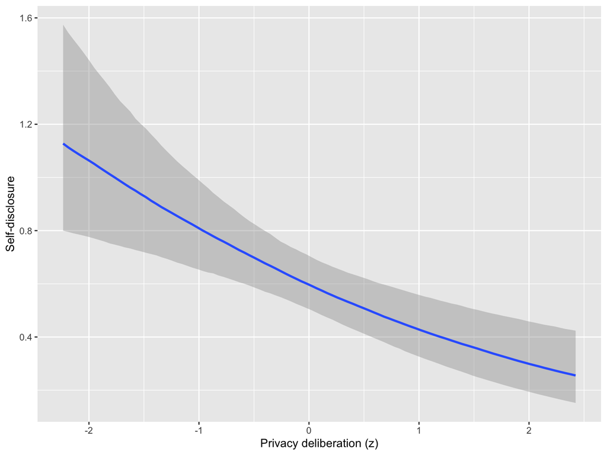

```r
run_hurdles(
  object = d,
  name = "self_disc_pridel",
  outcome = "self_disc",
  predictor = "pri_del_z",
  y_lab = "Self-disclosure",
  x_lab = "Privacy deliberation (z)"
  )
```

### Trust General

```
Some PIT values larger than 1! Largest:  1
Rounding PIT > 1 to 1.
```

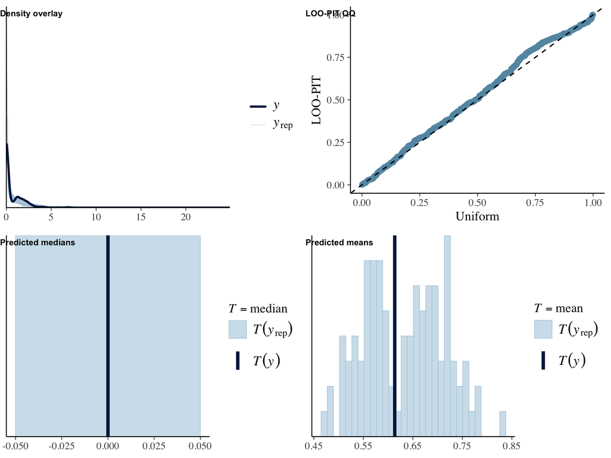

```
 Family: hurdle_gamma
  Links: mu = log; hu = logit
Formula: self_disc ~ 1 + age + male + edu + trust_gen_z
         hu ~ 1 + age + male + edu + trust_gen_z
   Data: object (Number of observations: 558)
  Draws: 4 chains, each with iter = 1000; warmup = 500; thin = 1;
         total post-warmup draws = 2000

Regression Coefficients:
               Estimate Est.Error l-95% CI u-95% CI Rhat Bulk_ESS Tail_ESS
Intercept          0.45      0.29    -0.08     1.04 1.00     3346     1603
hu_Intercept       1.24      0.37     0.53     1.95 1.00     3508     1751
age               -0.00      0.00    -0.01     0.01 1.01     3804     1507
male               0.01      0.14    -0.25     0.28 1.00     3385     1671
edu               -0.03      0.08    -0.19     0.13 1.00     3649     1558
trust_gen_z        0.03      0.07    -0.11     0.17 1.00     3258     1312
hu_age            -0.01      0.01    -0.02     0.00 1.00     4101     1526
hu_male           -0.07      0.19    -0.43     0.29 1.00     4177     1802
hu_edu            -0.21      0.11    -0.41    -0.00 1.00     3390     1521
hu_trust_gen_z    -0.34      0.09    -0.52    -0.17 1.00     4551     1369

Further Distributional Parameters:
      Estimate Est.Error l-95% CI u-95% CI Rhat Bulk_ESS Tail_ESS
shape     0.93      0.07     0.80     1.08 1.00     2803     1806

Draws were sampled using sampling(NUTS). For each parameter, Bulk_ESS
and Tail_ESS are effective sample size measures, and Rhat is the potential
scale reduction factor on split chains (at convergence, Rhat = 1).
```

```
Results of marginal effects:
    Outcome        term contrast estimate conf.low conf.high
1 self_disc         age    dY/dX  0.00314 -0.00371    0.0104
2 self_disc         edu    dY/dX  0.05910 -0.06647    0.1803
3 self_disc        male    1 - 0  0.03050 -0.18164    0.2624
4 self_disc trust_gen_z    dY/dX  0.13663  0.02913    0.2490
```

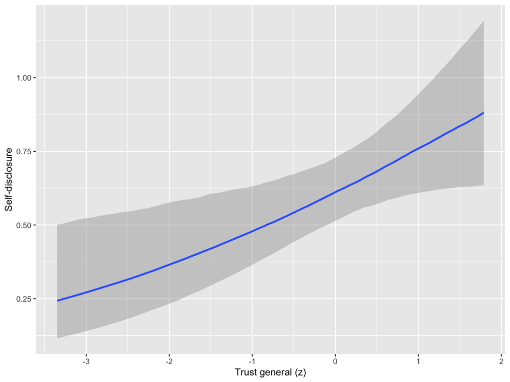

```r
run_hurdles(
  object = d,
  name = "self_disc_trust",
  outcome = "self_disc",
  predictor = "trust_gen_z",
  y_lab = "Self-disclosure",
  x_lab = "Trust general (z)"
  )
```

### Self-Efficacy

```
Some PIT values larger than 1! Largest:  1
Rounding PIT > 1 to 1.
```

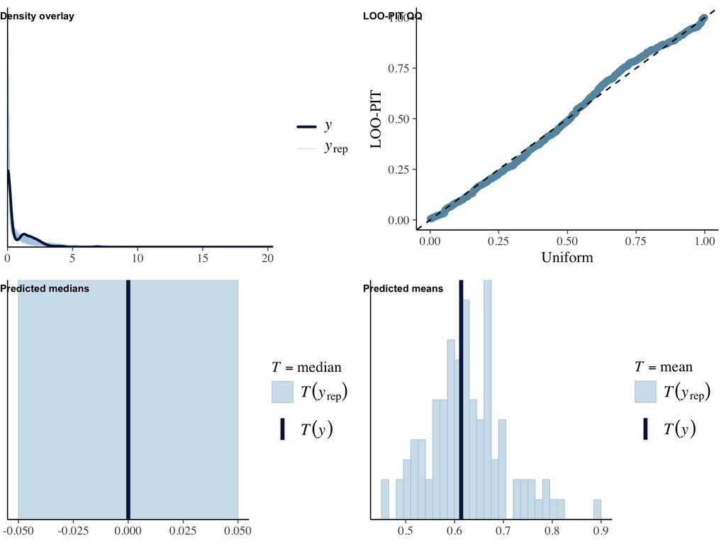

```
 Family: hurdle_gamma
  Links: mu = log; hu = logit
Formula: self_disc ~ 1 + age + male + edu + self_eff_z
         hu ~ 1 + age + male + edu + self_eff_z
   Data: object (Number of observations: 558)
  Draws: 4 chains, each with iter = 1000; warmup = 500; thin = 1;
         total post-warmup draws = 2000

Regression Coefficients:
              Estimate Est.Error l-95% CI u-95% CI Rhat Bulk_ESS Tail_ESS
Intercept         0.36      0.27    -0.16     0.90 1.00     3582     1540
hu_Intercept      1.11      0.38     0.36     1.87 1.00     3978     1741
age              -0.00      0.00    -0.01     0.01 1.00     3386     1488
male             -0.01      0.13    -0.28     0.25 1.00     3880     1670
edu              -0.05      0.08    -0.21     0.11 1.00     4262     1658
self_eff_z        0.25      0.07     0.11     0.39 1.00     2984     1833
hu_age           -0.01      0.01    -0.02     0.00 1.00     4083     1568
hu_male          -0.01      0.19    -0.36     0.37 1.00     3378     1379
hu_edu           -0.12      0.11    -0.35     0.11 1.00     3458     1484
hu_self_eff_z    -0.86      0.11    -1.07    -0.65 1.00     3842     1645

Further Distributional Parameters:
      Estimate Est.Error l-95% CI u-95% CI Rhat Bulk_ESS Tail_ESS
shape     0.97      0.08     0.82     1.12 1.00     3592     1777

Draws were sampled using sampling(NUTS). For each parameter, Bulk_ESS
and Tail_ESS are effective sample size measures, and Rhat is the potential
scale reduction factor on split chains (at convergence, Rhat = 1).
```

```
Results of marginal effects:
    Outcome       term contrast estimate conf.low conf.high
1 self_disc        age    dY/dX  0.00292 -0.00344     0.010
2 self_disc        edu    dY/dX  0.00336 -0.11486     0.125
3 self_disc       male    1 - 0 -0.00931 -0.19531     0.187
4 self_disc self_eff_z    dY/dX  0.39766  0.29292     0.521
```

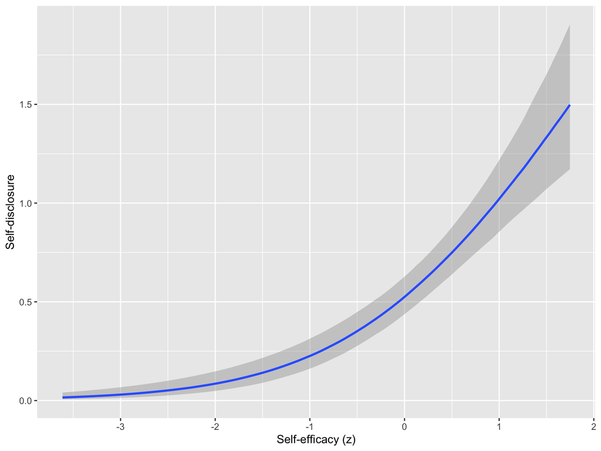

```r
run_hurdles(
  object = d,
  name = "self_disc_selfeff",
  outcome = "self_disc",
  predictor = "self_eff_z",
  y_lab = "Self-disclosure",
  x_lab = "Self-efficacy (z)"
  )
```

Let’s inspect how self-disclosure changes with a one-SD increase in self-efficacy, once starting from the lowest level of self-efficacy in our sample, and once ending at the highest level.

```r
effects_self_disc_selfeff_12 <-
  avg_comparisons(
    fit_self_disc_selfeff,
    variables = list(self_eff_z = 1),
    newdata = datagrid(self_eff_z = self_eff_lo, grid_type = "counterfactual")
    ) %>%
  pull(estimate) %>%
  round(2)

effects_self_disc_selfeff_67 <-
  avg_comparisons(
    fit_self_disc_selfeff,
    variables = list(self_eff_z = 1),
    newdata = datagrid(self_eff_z = self_eff_hi, grid_type = "counterfactual")
    ) %>%
  pull(estimate) %>%
  round(2)
```

Starting from the lowest level of self-efficacy, an increase of one standard deviation was associated with an increase in self-disclosure of 0.03 SD; ending at the highest level, the same increase was associated with an increase of 0.62 SD.

Let’s explore how self-disclosure differs between people with the lowest and the highest self-efficacy in our sample.

```r
self_disc_selfeff_1 <- fig_self_disc_selfeff$data %>% filter(self_eff_z == min(self_eff_z)) %>% pull(estimate__) %>% round(2)
self_disc_selfeff_7 <- fig_self_disc_selfeff$data %>% filter(self_eff_z == max(self_eff_z)) %>% pull(estimate__) %>% round(2)
```

People with the lowest self-efficacy had a predicted self-disclosure of 0.02 SD, whereas people with the highest self-efficacy had 1.5 SD.

### Visualization

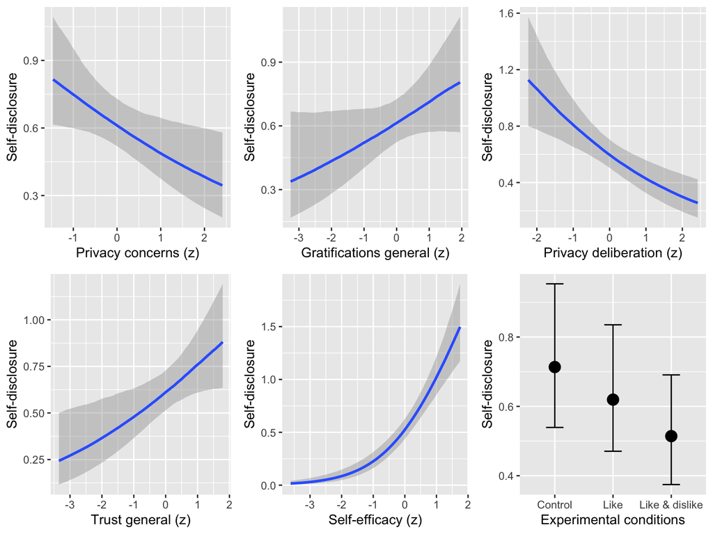

```r
fig_results_self_disc <-
  plot_grid(
    fig_self_disc_pricon,
    fig_self_disc_grats,
    fig_self_disc_pridel,
    fig_self_disc_trust,
    fig_self_disc_selfeff,
    fig_self_disc_ctrl
    ) %T>%
  print()
```

```r
ggsave("figures/results/self_disc/effects.pdf", fig_results_self_disc, width = 8, height = 8)
ggsave("figures/results/self_disc/effects.png", fig_results_self_disc, width = 8, height = 8)
```

### Table

```r
tab_slopes_self_disc <-
  label_slopes(
    list(
      slopes_self_disc_pricon,
      slopes_self_disc_grats,
      slopes_self_disc_pridel,
      slopes_self_disc_trust,
      slopes_self_disc_selfeff,
      slopes_self_disc_ctrl,
      slopes_self_disc_lkdslk
      )
    )

tab_slopes_self_disc %>%
  kable(digits = 2) %>%
  kable_styling("striped") %>%
  scroll_box(width = "100%")
```

| Outcome | Predictor | Estimate | LL | UL |
| --- | --- | --- | --- | --- |
| self_disc | Privacy concerns | -0.13 | -0.25 | -0.02 |
| self_disc | Expected gratifications | 0.09 | -0.02 | 0.20 |
| self_disc | Privacy deliberation | -0.19 | -0.30 | -0.09 |
| self_disc | Trust | 0.14 | 0.03 | 0.25 |
| self_disc | Self-efficacy | 0.40 | 0.29 | 0.52 |
| self_disc | Like & dislike vs. control | -0.20 | -0.47 | 0.05 |
| self_disc | Like vs. control | -0.09 | -0.37 | 0.18 |
| self_disc | Like vs. like & dislike | 0.10 | -0.14 | 0.34 |

## Communication vs. Self-Disclosure

The average marginal effects for both outcomes side by side: communication (number of words) and self-disclosure (in SD).

```r
tab_slopes_wide <-
  bind_rows(
    tab_slopes %>% filter(Outcome == "words"),
    tab_slopes_self_disc %>% filter(Outcome == "self_disc")
    ) %>%
  pivot_wider(
    names_from = Outcome,
    values_from = c(Estimate, LL, UL),
    names_glue = "{Outcome}_{.value}"
    ) %>%
  select(
    Predictor,
    words_Estimate, words_LL, words_UL,
    self_disc_Estimate, self_disc_LL, self_disc_UL
    ) %>%
  arrange(desc(Predictor))

tab_slopes_wide %>%
  kable(
    digits = 2,
    col.names = c("Predictor", "Estimate", "LL", "UL", "Estimate", "LL", "UL")
    ) %>%
  add_header_above(c(" " = 1, "Communication (words)" = 3, "Self-disclosure (SD)" = 3)) %>%
  kable_styling("striped") %>%
  scroll_box(width = "100%")
```

| Predictor | Communication (words) Estimate | Communication (words) LL | Communication (words) UL | Self-disclosure (SD) Estimate | Self-disclosure (SD) LL | Self-disclosure (SD) UL |
| --- | --- | --- | --- | --- | --- | --- |
| Like vs. control | -36 | -78 | 2 | -0.09 | -0.37 | 0.18 |
| Like & dislike vs. control | -48 | -90 | -11 | -0.20 | -0.47 | 0.05 |
| Like vs. like & dislike | 13 | -18 | 44 | 0.10 | -0.14 | 0.34 |
| Privacy concerns | -24 | -41 | -9 | -0.13 | -0.25 | -0.02 |
| Expected gratifications | 30 | 16 | 49 | 0.09 | -0.02 | 0.20 |
| Privacy deliberation | -37 | -56 | -22 | -0.19 | -0.30 | -0.09 |
| Trust | 30 | 14 | 50 | 0.14 | 0.03 | 0.25 |
| Self-efficacy | 70 | 53 | 92 | 0.40 | 0.29 | 0.52 |

All average marginal effects in one long table, including the effects of the popularity cues on the privacy calculus variables.

```r
tab_slopes_all <-
  bind_rows(tab_slopes, tab_slopes_self_disc) %>%
  mutate(Outcome = factor(Outcome, levels = unique(c("words", "self_disc", Outcome)))) %>%
  arrange(Outcome, desc(Predictor))

tab_slopes_all %>%
  kable(digits = 2) %>%
  kable_styling("striped") %>%
  scroll_box(width = "100%")
```

| Outcome | Predictor | Estimate | LL | UL |
| --- | --- | --- | --- | --- |
| words | Like vs. control | -36.00 | -78.00 | 2.00 |
| words | Like & dislike vs. control | -48.00 | -90.00 | -11.00 |
| words | Like vs. like & dislike | 13.00 | -18.00 | 44.00 |
| words | Privacy concerns | -24.00 | -41.00 | -9.00 |
| words | Expected gratifications | 30.00 | 16.00 | 49.00 |
| words | Privacy deliberation | -37.00 | -56.00 | -22.00 |
| words | Trust | 30.00 | 14.00 | 50.00 |
| words | Self-efficacy | 70.00 | 53.00 | 92.00 |
| self_disc | Like vs. control | -0.09 | -0.37 | 0.18 |
| self_disc | Like & dislike vs. control | -0.20 | -0.47 | 0.05 |
| self_disc | Like vs. like & dislike | 0.10 | -0.14 | 0.34 |
| self_disc | Privacy concerns | -0.13 | -0.25 | -0.02 |
| self_disc | Expected gratifications | 0.09 | -0.02 | 0.20 |
| self_disc | Privacy deliberation | -0.19 | -0.30 | -0.09 |
| self_disc | Trust | 0.14 | 0.03 | 0.25 |
| self_disc | Self-efficacy | 0.40 | 0.29 | 0.52 |
| Privacy concerns | Like vs. control | 0.03 | -0.29 | 0.36 |
| Privacy concerns | Like & dislike vs. control | 0.17 | -0.15 | 0.51 |
| Privacy concerns | Like vs. like & dislike | -0.16 | -0.50 | 0.18 |
| Expected gratifications | Like vs. control | -0.17 | -0.42 | 0.08 |
| Expected gratifications | Like & dislike vs. control | -0.21 | -0.47 | 0.06 |
| Expected gratifications | Like vs. like & dislike | 0.03 | -0.21 | 0.30 |
| Privacy deliberation | Like vs. control | -0.01 | -0.25 | 0.23 |
| Privacy deliberation | Like & dislike vs. control | -0.04 | -0.29 | 0.20 |
| Privacy deliberation | Like vs. like & dislike | 0.03 | -0.21 | 0.27 |
| Trust | Like vs. control | -0.15 | -0.34 | 0.06 |
| Trust | Like & dislike vs. control | -0.12 | -0.34 | 0.07 |
| Trust | Like vs. like & dislike | -0.02 | -0.22 | 0.20 |
| Self-efficacy | Like vs. control | -0.09 | -0.29 | 0.11 |
| Self-efficacy | Like & dislike vs. control | -0.09 | -0.31 | 0.12 |
| Self-efficacy | Like vs. like & dislike | 0.00 | -0.21 | 0.21 |

Back to top

## References

Omarzu, Julia. 2000. “A Disclosure Decision Model: Determining How and When Individuals Will Self-Disclose.” *Personality and Social Psychology Review* 4 (2): 174–85. https://doi.org/10.1207/S15327957PSPR0402_5.

Rohrer, Julia M. 2018. “Thinking Clearly about Correlations and Causation: Graphical Causal Models for Observational Data.” *Advances in Methods and Practices in Psychological Science* 24 (2): 251524591774562. https://doi.org/10.1177/2515245917745629.